[figure not shown]

- .ipynb

# Model 4

## Contents

**Show code cell content Hide code cell content**

```r
# Source the package setup script
source("C:/Users/bmc82/Documents/UF/PhD_Projects/DISSERTATION_MANUSCRIPT/Chapter_3/chapter3_data_analysis/scripts/00_setup_packages.R")

# Source the custom graphing functions
source("C:/Users/bmc82/Documents/UF/PhD_Projects/DISSERTATION_MANUSCRIPT/Chapter_3/chapter3_data_analysis/scripts/01_graphing_functions.R")
```

[output not shown]

[output not shown]

[output not shown]

[output not shown]

[output not shown]

[output not shown]

[output not shown]

[output not shown]

[output not shown]

[output not shown]

[output not shown]

[output not shown]

[output not shown]

[output not shown]

[output not shown]

[output not shown]

[output not shown]

[output not shown]

[output not shown]

[output not shown]

[output not shown]

[output not shown]

[output not shown]

[output not shown]

[output not shown]

[output not shown]

[output not shown]

[output not shown]

[output not shown]

[output not shown]

[output not shown]

[output not shown]

[output not shown]

[output not shown]

[output not shown]

[output not shown]

[output not shown]

[output not shown]

[output not shown]

[output not shown]

[output not shown]

[output not shown]

[output not shown]

[output not shown]

[output not shown]

[output not shown]

[output not shown]

[output not shown]

[output not shown]

[output not shown]

[output not shown]

[output not shown]

[output not shown]

[output not shown]

[output not shown]

[output not shown]

[output not shown]

[output not shown]

[output not shown]

[output not shown]

[output not shown]

[output not shown]

[output not shown]

[output not shown]

[output not shown]

[output not shown]

[output not shown]

[output not shown]

[output not shown]

[output not shown]

[output not shown]

[output not shown]

[output not shown]

[output not shown]

[output not shown]

[output not shown]

[output not shown]

[output not shown]

[output not shown]

[output not shown]

[output not shown]

[output not shown]

[output not shown]

[output not shown]

[output not shown]

[output not shown]

[output not shown]

[output not shown]

[output not shown]

[output not shown]

[output not shown]

[output not shown]

[output not shown]

[output not shown]

[output not shown]

[output not shown]

# Model 4

## Question

How do intrinsic factors (*sex*, *size*) influence *P. cristatus* dorsal body color patterns?

## Objective

Test for the effect of *sex* and *size* on *P. cristatus* dorsal body color pattern metrics.

## Method

### 1. Load cleaned data.

We start by loading the cleaned data from the “03_data_cleaning” pipeline. This data has already undergone transformations and contains relevant metrics for our models.

```r
data_m4_clean <- read.csv("C:/Users/bmc82/Documents/UF/PhD_Projects/DISSERTATION_MANUSCRIPT/Chapter_3/chapter3_data_analysis/data/cleaned/data_m4_clean.csv")
```

### 2. Prepare data for modeling.

#### **Continuous predictors**

```r
# Convert categorical variables to factors
columns_to_convert_m4 <- c("Sex")

data_m4_clean <- data_m4_clean %>%
    mutate(across(all_of(columns_to_convert_m4), as.factor))

# Set reference category for categorical predictors
data_m4_clean$Sex <- relevel(data_m4_clean$Sex, ref = "M")


# Convert continuous variables to numeric
columns_to_convert_m4 <- c("Size", "e_max", "Filter_max", "e_prop", "R_c", "G_c", "B_c")

data_m4_clean <- data_m4_clean %>%
    mutate(across(all_of(columns_to_convert_m4), as.numeric))

# Standardize continuous variables
data_m4_clean <-
    data_m4_clean %>%
    mutate(Size_center = (Size - mean(Size)) / (2 * sd(Size)))
```

### 3. Visualize response variable distributions

To understand the distributions of our response variables, we plot density curves. This helps confirm whether a Gamma distribution is appropriate for modeling, as Gamma is suited for positively skewed, continuous data.

**Show code cell content Hide code cell content**

```r
#| label: m4 - visualize response variable ranges

p_response_m4_e_max <- data_m4_clean %>%
    ggplot(aes(x = e_max)) +
    geom_density(fill = "#69b3a2", color = "#e9ecef", alpha = 0.8) +
    theme_bw() +
    labs(title = "e_max") +
    theme_bw(base_size = 8) +
    theme(
        panel.grid.major = element_blank(),
        panel.grid.minor = element_blank(),
        panel.background = element_rect(fill = "white", color = "black"),
        axis.text.x = element_text(size = 8),
        axis.title.x = element_text(size = 8),
        axis.text.y = element_text(size = 8),
        axis.title.y = element_text(size = 8),
        plot.title = element_text(size = 10),
        legend.position = "none"
    )

p_response_m4_Filter_max <- data_m4_clean %>%
    ggplot(aes(x = Filter_max)) +
    geom_density(fill = "#69b3a2", color = "#e9ecef", alpha = 0.8) +
    theme_bw() +
    labs(title = "Filter_max") +
    theme_bw(base_size = 8) +
    theme(
        panel.grid.major = element_blank(),
        panel.grid.minor = element_blank(),
        panel.background = element_rect(fill = "white", color = "black"),
        axis.text.x = element_text(size = 8),
        axis.title.x = element_text(size = 8),
        axis.text.y = element_text(size = 8),
        axis.title.y = element_text(size = 8),
        plot.title = element_text(size = 10),
        legend.position = "none"
    )

p_response_m4_e_prop <- data_m4_clean %>%
    ggplot(aes(x = e_prop)) +
    geom_density(fill = "#69b3a2", color = "#e9ecef", alpha = 0.8) +
    theme_bw() +
    labs(title = "e_prop") +
    theme_bw(base_size = 8) +
    theme(
        panel.grid.major = element_blank(),
        panel.grid.minor = element_blank(),
        panel.background = element_rect(fill = "white", color = "black"),
        axis.text.x = element_text(size = 8),
        axis.title.x = element_text(size = 8),
        axis.text.y = element_text(size = 8),
        axis.title.y = element_text(size = 8),
        plot.title = element_text(size = 10),
        legend.position = "none"
    )

p_response_m4_R_c <- data_m4_clean %>%
    ggplot(aes(x = R_c)) +
    geom_density(fill = "#69b3a2", color = "#e9ecef", alpha = 0.8) +
    theme_bw() +
    labs(title = "R_c") +
    theme_bw(base_size = 8) +
    theme(
        panel.grid.major = element_blank(),
        panel.grid.minor = element_blank(),
        panel.background = element_rect(fill = "white", color = "black"),
        axis.text.x = element_text(size = 8),
        axis.title.x = element_text(size = 8),
        axis.text.y = element_text(size = 8),
        axis.title.y = element_text(size = 8),
        plot.title = element_text(size = 10),
        legend.position = "none"
    )

p_response_m4_G_c <- data_m4_clean %>%
    ggplot(aes(x = G_c)) +
    geom_density(fill = "#69b3a2", color = "#e9ecef", alpha = 0.8) +
    theme_bw() +
    labs(title = "G_c") +
    theme_bw(base_size = 8) +
    theme(
        panel.grid.major = element_blank(),
        panel.grid.minor = element_blank(),
        panel.background = element_rect(fill = "white", color = "black"),
        axis.text.x = element_text(size = 8),
        axis.title.x = element_text(size = 8),
        axis.text.y = element_text(size = 8),
        axis.title.y = element_text(size = 8),
        plot.title = element_text(size = 10),
        legend.position = "none"
    )

p_response_m4_B_c <- data_m4_clean %>%
    ggplot(aes(x = B_c)) +
    geom_density(fill = "#69b3a2", color = "#e9ecef", alpha = 0.8) +
    theme_bw() +
    labs(title = "B_c") +
    theme_bw(base_size = 8) +
    theme(
        panel.grid.major = element_blank(),
        panel.grid.minor = element_blank(),
        panel.background = element_rect(fill = "white", color = "black"),
        axis.text.x = element_text(size = 8),
        axis.title.x = element_text(size = 8),
        axis.text.y = element_text(size = 8),
        axis.title.y = element_text(size = 8),
        plot.title = element_text(size = 10),
        legend.position = "none"
    )

# Combine plots for easy visualization
plot_m4_dorsalbody_patterns <- ggarrange(
    p_response_m4_e_max,
    p_response_m4_Filter_max,
    p_response_m4_e_prop,
    p_response_m4_R_c,
    p_response_m4_G_c,
    p_response_m4_B_c,
    ncol = 3,
    nrow = 2
)

annotate_figure(
    plot_m4_dorsalbody_patterns,
    top = text_grob("Ranges of response variables")
)


ggsave("C:/Users/bmc82/Documents/UF/PhD_Projects/DISSERTATION_MANUSCRIPT/Chapter_3/chapter3_data_analysis/images/plot_m4_dorsalbody_patterns.png", plot = plot_m4_dorsalbody_patterns, width = 6, height = 3, units = "in", dpi = 300)
```

[figure not shown]

**Show code cell source Hide code cell source**

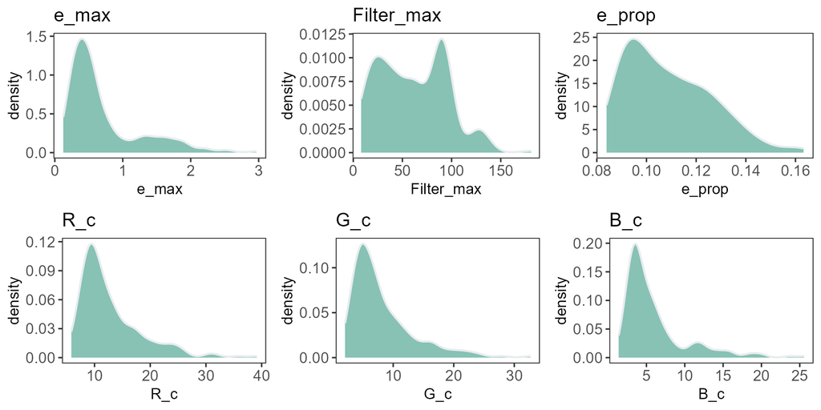

```r
# Convert images to base64
plot_m4_dorsalbody_patterns <- knitr::image_uri("C:/Users/bmc82/Documents/UF/PhD_Projects/DISSERTATION_MANUSCRIPT/Chapter_3/chapter3_data_analysis/images/plot_m4_dorsalbody_patterns.png")

# Create the HTML
html_dorsalbody_patterns <- paste0("
<style>
  body, html {
    margin: 0;
    padding: 0;
    /* If you want no horizontal scrollbar: */
    overflow-x: hidden;
  }
  img {
    max-width: 600px;   /* ~6 inches at 100 dpi screen rendering */
    width: 100%;
    height: auto;
    display: block;
    margin-bottom: 20px;
    border: 1px solid #ccc;
  }
</style>

<img src='", plot_m4_dorsalbody_patterns, "' alt='Dorsal Body Pattern Metrics'>
")

# Display the HTML
IRdisplay::display_html(html_dorsalbody_patterns)
```

### 4. Justification for GLMs and Bayesian methods

#### **Why GLMs?**

Generalized Linear Models (GLMs) are used because our response variables are continuous, non-negative, and right-skewed, which violates the assumptions of linear regression. The Gamma distribution with a log link function allows us to model these variables appropriately.

#### **Why Bayesian methods?**

Bayesian GLMs were chosen over frequentist approaches because:

- **Sparse data**: Bayesian methods handle sparse datasets more robustly.
- **Priors**: They allow us to incorporate prior knowledge, improving model performance.
- **Posterior distributions**: Bayesian models provide posterior distributions, offering a full view of parameter uncertainty.

### 4. Define priors

#### **What are priors?**

In Bayesian statistics, priors represent our beliefs about parameter values before analyzing the data. These beliefs are mathematically expressed as probability distributions. Priors guide the model, especially when data are sparse or when the signal-to-noise ratio is low.

#### **Why priors matter:**

- **Prevent overfitting**: Priors discourage extreme parameter estimates unless strongly supported by the data.
- **Balance restrictiveness and flexibility**: Weakly informative priors let the data dominate while providing reasonable bounds.
- **Leverage existing knowledge**: Informative priors incorporate previous research or domain expertise, improving accuracy in well-studied systems.

#### **How priors work in this analysis:**

We combine the priors (representing initial beliefs) with the likelihood of the observed data to compute posterior distributions, which reflect updated beliefs after observing the data.

The general formula is:

$\begin{aligned} \text{Posterior } \alpha \text{ Likelihood} * \text{Prior} \end{aligned}$

#### **Model family and formula**

The response variables (**e_max**, **Filter_max**, **e_prop**, **R**, **G**, **B**) are continuous and positively skewed. We model these variables using a Gamma distribution with a log link function:

$\begin{aligned} y_{i} &\sim \text{Gamma}(\mu_{i}, \phi) \end{aligned}$

The mean $\mu_i$ (on the log scale) is modeled as:

$\begin{split} \begin{aligned} & \log(\mu_{i}) = \alpha + \beta x_{i} \\ \end{aligned} \end{split}$

Where:

- **$y_{i}$**: Response variable for observation $i$
- **$\mu_{i}$**: Mean of the Gamma distribution for $i$ (on the log scale)
- **$\phi$**: Shape parameter (controls variability)
- **$\alpha$**: Intercept, mean value of $\log(\mu)$ when predictors are at baseline
- **$beta$**: Coefficient/slope for predictor $x_{i}$, representing the effect of $x_{i}$ on $\log(\mu)$

#### **Chosen priors and rationale**

  These priors ensure the intercept reflects realistic values for the response variables while allowing for moderate variability.

**Slope ($\beta$)**: The slope reflects the rate of change in $\log(\mu)$ for a one-unit change in the predictor. On the original scale, this translates to:

$\begin{split} \begin{aligned} \frac{y_{x+1}}{y_x} &= \frac{e^{(\alpha + \beta(x+1))}}{e^{(\alpha + \beta x)}} \\ &= \frac{e^{(\alpha + \beta x + \beta)}}{e^{(\alpha + \beta x)}} \\ &= e^{(\alpha + \beta x)} \times \frac{e^{\beta}}{e^{(\alpha + \beta x)}} \\ &= e^{\beta} \\ & \quad \quad \quad \text{OR} \\ & \text{Scaling factor} = e^{\beta} \end{aligned} \end{split}$

For example:

- If $\beta = 0.1$, a one-unit increase in the predictor scales $\mu$ by $e^{0.1} \approx 1.10$ (a 10% increase).
- If $\beta = -0.1$, a one-unit increase scales $\mu$ by $e^{-0.1} \approx 0.91$ (a 9% decrease).

We don’t know how our predictors will affect the response, so we use a weakly informative prior:

$\begin{aligned} \beta \approx N(0,0.5) \end{aligned}$

This prior assumes no effect of the predictor on average ($e^{0} = 1$, and allows moderate positive or negative effects, spanning approximately $[-1, 1]$ on the log scale ($e^{-1} \approx 0.37$ to $e^{1} \approx 2.72$ on the original scale). So $\mu$ of each response variable will not exceed a minimum of $\mu * 0.37$ and maximum of $\mu * 2.72$.

**Shape parameter ($\phi$)**: In a Gamma distribution, variability is tied to the shape parameter ($\phi$) that governs how the spread relates to the mean. Smaller $\phi$ values indicate greater variability. We will set the shape parameter to a weakly informative $\gamma(0.01, 0.01)$ which makes most probability mass concentrated near zero with a long tail so that the data will drive the distribution of variability values.

$\begin{aligned} \phi \approx \text{Gamma}(0.01,0.01) \end{aligned}$

This ensures strictly positive values but keeps a wide range of plausible variability values.

[figure not shown]

#### **Visualizing priors**

To validate these priors, we run models sampling only from the priors (sample_prior = “only”) and inspect their outputs to ensure they align with our expectations.

> **Note:** We will run these models in RStudio to be consistent because the rstan package sometimes does not like Jupyter. The models were saved in RStudio and loaded below. We left the code chunks as comments for reference.

**Show code cell content Hide code cell content**

```r
# # Set seed for reproducibility
# set.seed(5678)
# # e_max
# m4_priors_e_max <- brm(
#     family = Gamma(link = "log"),
#     formula = e_max ~ 1 + Size_center + Sex,
#     data = data_m4_clean,
#     prior = c(
#         prior(normal(log(1), 0.5), class = "Intercept"),
#         prior(normal(0, 0.5), class = "b"),
#         prior(gamma(0.01, 0.01), class = "shape")
#     ),
#     sample_prior = "only",
#     save_pars = save_pars(all = TRUE),
#     control = list(adapt_delta = 0.99, max_treedepth = 12),
#     iter = 15000,
#     warmup = 5000,
#     chains = 2,
#     cores = parallel::detectCores(logical=FALSE),
#     backend = "rstan"
# )
# saveRDS(m4_priors_e_max, file = "C:/Users/bmc82/Documents/UF/PhD_Projects/DISSERTATION_MANUSCRIPT/Chapter_3/chapter3_data_analysis/data/models/m4_priors_e_max.rds")


# # Set seed for reproducibility
# set.seed(5678)
# # Filter_max
# m4_priors_Filter_max <- brm(
#     family = Gamma(link = "log"),
#     formula = Filter_max ~ 1 + Size_center + Sex,
#     data = data_m4_clean,
#     prior = c(
#         prior(normal(log(100), 0.5), class = "Intercept"),
#         prior(normal(0, 0.5), class = "b"),
#         prior(gamma(0.01, 0.01), class = "shape")
#     ),
#     sample_prior = "only",
#     save_pars = save_pars(all = TRUE),
#     control = list(adapt_delta = 0.99, max_treedepth = 12),
#     iter = 15000,
#     warmup = 5000,
#     chains = 2,
#     cores = parallel::detectCores(logical=FALSE),
#     backend = "rstan"
# )
# saveRDS(m4_priors_Filter_max, file = "C:/Users/bmc82/Documents/UF/PhD_Projects/DISSERTATION_MANUSCRIPT/Chapter_3/chapter3_data_analysis/data/models/m4_priors_Filter_max.rds")

# # Set seed for reproducibility
# set.seed(5678)
# # e_prop
# m4_priors_e_prop <- brm(
#     family = Gamma(link = "log"),
#     formula = e_prop ~ 1 + Size_center + Sex,
#     data = data_m4_clean,
#     prior = c(
#         prior(normal(log(0.10), 0.5), class = "Intercept"),
#         prior(normal(0, 0.5), class = "b"),
#         prior(gamma(0.01, 0.01), class = "shape")
#     ),
#     sample_prior = "only",
#     save_pars = save_pars(all = TRUE),
#     control = list(adapt_delta = 0.99, max_treedepth = 12),
#     iter = 15000,
#     warmup = 5000,
#     chains = 2,
#     cores = parallel::detectCores(logical=FALSE),
#     backend = "rstan"
# )
# saveRDS(m4_priors_e_prop, file = "C:/Users/bmc82/Documents/UF/PhD_Projects/DISSERTATION_MANUSCRIPT/Chapter_3/chapter3_data_analysis/data/models/m4_priors_e_prop.rds")


# # Set seed for reproducibility
# set.seed(5678)
# # R
# m4_priors_R_c <- brm(
#     family = Gamma(link = "log"),
#     formula = R_c ~ 1 + Size_center + Sex,
#     data = data_m4_clean,
#     prior = c(
#         prior(normal(log(10), 0.5), class = "Intercept"),
#         prior(normal(0, 0.5), class = "b"),
#         prior(gamma(0.01, 0.01), class = "shape")
#     ),
#     sample_prior = "only",
#     save_pars = save_pars(all = TRUE),
#     control = list(adapt_delta = 0.99, max_treedepth = 12),
#     iter = 15000,
#     warmup = 5000,
#     chains = 2,
#     cores = parallel::detectCores(logical=FALSE),
#     backend = "rstan"
# )
# saveRDS(m4_priors_R_c, file = "C:/Users/bmc82/Documents/UF/PhD_Projects/DISSERTATION_MANUSCRIPT/Chapter_3/chapter3_data_analysis/data/models/m4_priors_R_c.rds")

# # Set seed for reproducibility
# set.seed(5678)
# # G
# m4_priors_G_c <- brm(
#     family = Gamma(link = "log"),
#     formula = G_c ~ 1 + Size_center + Sex,
#     data = data_m4_clean,
#     prior = c(
#         prior(normal(log(10), 0.5), class = "Intercept"),
#         prior(normal(0, 0.5), class = "b"),
#         prior(gamma(0.01, 0.01), class = "shape")
#     ),
#     sample_prior = "only",
#     save_pars = save_pars(all = TRUE),
#     control = list(adapt_delta = 0.99, max_treedepth = 12),
#     iter = 15000,
#     warmup = 5000,
#     chains = 2,
#     cores = parallel::detectCores(logical=FALSE),
#     backend = "rstan"
# )
# saveRDS(m4_priors_G_c, file = "C:/Users/bmc82/Documents/UF/PhD_Projects/DISSERTATION_MANUSCRIPT/Chapter_3/chapter3_data_analysis/data/models/m4_priors_G_c.rds")


# # Set seed for reproducibility
# set.seed(5678)
# # B
# m4_priors_B_c <- brm(
#     family = Gamma(link = "log"),
#     formula = B_c ~ 1 + Size_center + Sex,
#     data = data_m4_clean,
#     prior = c(
#         prior(normal(log(10), 0.5), class = "Intercept"),
#         prior(normal(0, 0.5), class = "b"),
#         prior(gamma(0.01, 0.01), class = "shape")
#     ),
#     sample_prior = "only",
#     save_pars = save_pars(all = TRUE),
#     control = list(adapt_delta = 0.99, max_treedepth = 12),
#     iter = 15000,
#     warmup = 5000,
#     chains = 2,
#     cores = parallel::detectCores(logical=FALSE),
#     backend = "rstan"
# )
# saveRDS(m4_priors_B_c, file = "C:/Users/bmc82/Documents/UF/PhD_Projects/DISSERTATION_MANUSCRIPT/Chapter_3/chapter3_data_analysis/data/models/m4_priors_B_c.rds")
```

**Show code cell content Hide code cell content**

```r
# Load models
m4_priors_e_max <- readRDS("C:/Users/bmc82/Documents/UF/PhD_Projects/DISSERTATION_MANUSCRIPT/Chapter_3/chapter3_data_analysis/data/models/m4_priors_e_max.rds")
m4_priors_Filter_max <- readRDS("C:/Users/bmc82/Documents/UF/PhD_Projects/DISSERTATION_MANUSCRIPT/Chapter_3/chapter3_data_analysis/data/models/m4_priors_Filter_max.rds")
m4_priors_e_prop <- readRDS("C:/Users/bmc82/Documents/UF/PhD_Projects/DISSERTATION_MANUSCRIPT/Chapter_3/chapter3_data_analysis/data/models/m4_priors_e_prop.rds")
m4_priors_R_c <- readRDS("C:/Users/bmc82/Documents/UF/PhD_Projects/DISSERTATION_MANUSCRIPT/Chapter_3/chapter3_data_analysis/data/models/m4_priors_R_c.rds")
m4_priors_G_c <- readRDS("C:/Users/bmc82/Documents/UF/PhD_Projects/DISSERTATION_MANUSCRIPT/Chapter_3/chapter3_data_analysis/data/models/m4_priors_G_c.rds")
m4_priors_B_c <- readRDS("C:/Users/bmc82/Documents/UF/PhD_Projects/DISSERTATION_MANUSCRIPT/Chapter_3/chapter3_data_analysis/data/models/m4_priors_B_c.rds")

# Extract results
prior_samples_m4_e_max <- as_draws_df(m4_priors_e_max)
prior_samples_m4_Filter_max <- as_draws_df(m4_priors_Filter_max)
prior_samples_m4_e_prop <- as_draws_df(m4_priors_e_prop)
prior_samples_m4_R_c <- as_draws_df(m4_priors_R_c)
prior_samples_m4_G_c <- as_draws_df(m4_priors_G_c)
prior_samples_m4_B_c <- as_draws_df(m4_priors_B_c)
```

**Show code cell content Hide code cell content**

```r
# List of datasets and labels
prior_samples <- list(
    e_max = prior_samples_m4_e_max,
    Filter_max = prior_samples_m4_Filter_max,
    e_prop = prior_samples_m4_e_prop,
    R_c = prior_samples_m4_R_c,
    G_c = prior_samples_m4_G_c,
    B_c = prior_samples_m4_B_c
)

# Custom labels for predictors
custom_labels_priors <- c(
    "b_Size_center" = "Size",
    "b_SexF" = "Sex"
)

# Custom labels for intercept
custom_labels_priors_intercept <- c(
    "b_Intercept" = "Intercept"
)

# Generate predictor plots
prior_plots <- lapply(
    names(prior_samples),
    function(label) {
        generate_posterior_plot(
            prior_samples[[label]],
            regex_pars = c(
              "b_Size_center",
              "b_SexF"
              ),
            x_range = c(-5, 5),
            custom_labels = custom_labels_priors,
            axis_title_y = label %in% c("e_max", "R_c")
        )
    }
)
names(prior_plots) <- names(prior_samples)

# Generate intercept plots
prior_plots_intercept <- lapply(
    names(prior_samples),
    function(label) {
        generate_posterior_plot(
            prior_samples[[label]],
            regex_pars = c("b_Intercept"),
            x_range = c(-6, 6),
            custom_labels = custom_labels_priors_intercept,
            axis_title_y = label %in% c("e_max", "R_c")
        )
    }
)
names(prior_plots_intercept) <- names(prior_samples)

# Add grey bars with labels for each plot
prior_plots_with_bars <- mapply(
    function(plot, label) {
        patchwork::wrap_elements(create_top_bar(label)) / plot +
            patchwork::plot_layout(heights = c(0.2, 1))
    },
    prior_plots,
    names(prior_plots),
    SIMPLIFY = FALSE
)

prior_plots_intercept_with_bars <- mapply(
    function(plot, label) {
        patchwork::wrap_elements(create_top_bar(label)) / plot +
            patchwork::plot_layout(heights = c(0.2, 1))
    },
    prior_plots_intercept,
    names(prior_plots_intercept),
    SIMPLIFY = FALSE
)


# Combine predictor plots into a 2x3 grid
plot_priors_m4 <- patchwork::wrap_plots(
    prior_plots_with_bars[c("e_max", "Filter_max", "e_prop", "R_c", "G_c", "B_c")],
    ncol = 3
) +
    patchwork::plot_layout(guides = "collect")

# Combine intercept plots into a 2x3 grid
plot_priors_intercept_m4 <- patchwork::wrap_plots(
    prior_plots_intercept_with_bars[c("e_max", "Filter_max", "e_prop", "R_c", "G_c", "B_c")],
    ncol = 3
) +
    patchwork::plot_layout(guides = "collect")

# Add a unified x-axis label for predictor plots
plot_priors_m4 <- plot_priors_m4 +
    patchwork::plot_annotation(
        caption = "Expected value of the response (log scale)",
        theme = theme(plot.caption = element_text(hjust = 0.55, size = 10))
    )

# Add a unified x-axis label for intercept plots
plot_priors_intercept_m4 <- plot_priors_intercept_m4 +
    patchwork::plot_annotation(
        caption = "Expected value of the response (log scale)",
        theme = theme(plot.caption = element_text(hjust = 0.5, size = 10))
    )


ggsave("C:/Users/bmc82/Documents/UF/PhD_Projects/DISSERTATION_MANUSCRIPT/Chapter_3/chapter3_data_analysis/images/plot_priors_m4.png", plot = plot_priors_m4, width = 6, height = 4.5, units = "in", dpi = 300)

ggsave("C:/Users/bmc82/Documents/UF/PhD_Projects/DISSERTATION_MANUSCRIPT/Chapter_3/chapter3_data_analysis/images/plot_priors_intercept_m4.png", plot = plot_priors_intercept_m4, width = 6, height = 4.5, units = "in", dpi = 300)
```

[output not shown]

[output not shown]

[output not shown]

[output not shown]

[output not shown]

[output not shown]

[output not shown]

[output not shown]

[output not shown]

[output not shown]

[output not shown]

[output not shown]

[output not shown]

[output not shown]

[output not shown]

[output not shown]

[output not shown]

[output not shown]

[output not shown]

[output not shown]

[output not shown]

[output not shown]

[output not shown]

[output not shown]

[output not shown]

**Show code cell source Hide code cell source**

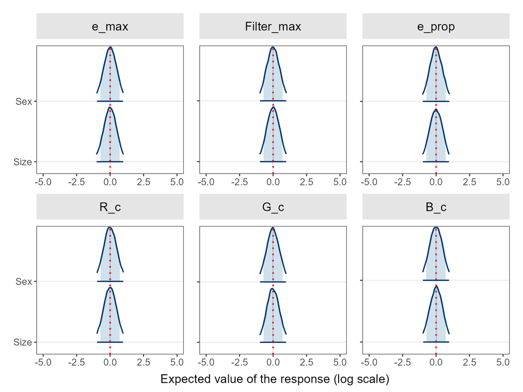

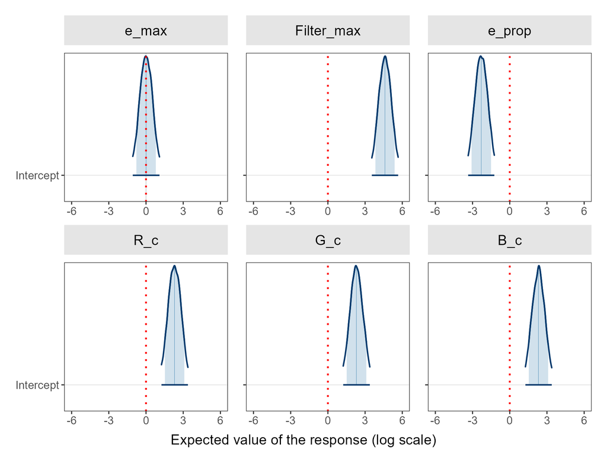

```r
# Convert images to base64 (assuming these return base64 data URIs)
plot_priors_m4 <- knitr::image_uri("C:/Users/bmc82/Documents/UF/PhD_Projects/DISSERTATION_MANUSCRIPT/Chapter_3/chapter3_data_analysis/images/plot_priors_m4.png")
plot_priors_intercept_m4 <- knitr::image_uri("C:/Users/bmc82/Documents/UF/PhD_Projects/DISSERTATION_MANUSCRIPT/Chapter_3/chapter3_data_analysis/images/plot_priors_intercept_m4.png")

# Create the HTML
html_priors <- paste0("
  <style>
    .image-row {
      display: flex;
      gap: 20px;
      justify-content: center;
      align-items: flex-start;
    }
    .image-row img {
      max-width: 100%;
      height: auto;
      border: 1px solid #ccc;
    }
  </style>
<div class='image-row'>
  <img src='", plot_priors_m4, "' alt='Prior Plot'>
</div>
<div class='image-row'>
  <img src='", plot_priors_intercept_m4, "' alt='Intercept Prior Plot'>
</div>
")

# Display the HTML
IRdisplay::display_html(html_priors)
```

### 6. Run final models

Now that we have finalized the model parameters, we fit models using the actual data and compare them to null models to assess the significance of predictors.

> **Note:** We will run these models in RStudio to be consistent because the rstan package sometimes does not like Jupyter. The models were saved in RStudio and loaded below. We left the code chunks as comments for reference.

**Show code cell content Hide code cell content**

```r
# # Set seed for reproducibility
# set.seed(5678)
# # null model (for comparison)
# m4v0_e_max <- brm(
#     family = Gamma(link = "log"),
#     formula = e_max ~ 1,
#     data = data_m4_clean,
#     prior = c(
#         prior(normal(log(1), 0.5), class = "Intercept"),
#         prior(gamma(0.01, 0.01), class = "shape")
#     ),
#     sample_prior = TRUE,
#     save_pars = save_pars(all = TRUE),
#     control = list(adapt_delta = 0.99, max_treedepth = 12),
#     iter = 15000,
#     warmup = 5000,
#     chains = 2,
#     cores = parallel::detectCores(logical=FALSE),
#     backend = "rstan"
# )
# saveRDS(m4v0_e_max, file = "C:/Users/bmc82/Documents/UF/PhD_Projects/DISSERTATION_MANUSCRIPT/Chapter_3/chapter3_data_analysis/data/models/m4v0_e_max.rds")


# # Set seed for reproducibility
# set.seed(5678)
# # e_max (Size & Sex)
# m4v1_e_max <- brm(
#     family = Gamma(link = "log"),
#     formula = e_max ~ 1 + Size_center + Sex,
#     data = data_m4_clean,
#     prior = c(
#         prior(normal(log(1), 0.5), class = "Intercept"),
#         prior(normal(0, 0.5), class = "b"),
#         prior(gamma(0.01, 0.01), class = "shape")
#     ),
#     sample_prior = TRUE,
#     save_pars = save_pars(all = TRUE),
#     control = list(adapt_delta = 0.99, max_treedepth = 12),
#     iter = 15000,
#     warmup = 5000,
#     chains = 2,
#     cores = parallel::detectCores(logical=FALSE),
#     backend = "rstan"
# )
# saveRDS(m4v1_e_max, file = "C:/Users/bmc82/Documents/UF/PhD_Projects/DISSERTATION_MANUSCRIPT/Chapter_3/chapter3_data_analysis/data/models/m4v1_e_max.rds")
```

**Show code cell content Hide code cell content**

```r
# # Set seed for reproducibility
# set.seed(5678)
# # null model (for comparison)
# m4v0_Filter_max <- brm(
#     family = Gamma(link = "log"),
#     formula = Filter_max ~ 1,
#     data = data_m4_clean,
#     prior = c(
#         prior(normal(log(100), 0.5), class = "Intercept"),
#         prior(gamma(0.01, 0.01), class = "shape")
#     ),
#     sample_prior = TRUE,
#     save_pars = save_pars(all = TRUE),
#     control = list(adapt_delta = 0.99, max_treedepth = 12),
#     iter = 15000,
#     warmup = 5000,
#     chains = 2,
#     cores = parallel::detectCores(logical=FALSE),
#     backend = "rstan"
# )
# saveRDS(m4v0_Filter_max, file = "C:/Users/bmc82/Documents/UF/PhD_Projects/DISSERTATION_MANUSCRIPT/Chapter_3/chapter3_data_analysis/data/models/m4v0_Filter_max.rds")


# # Set seed for reproducibility
# set.seed(5678)
# # Filter_max (Size & Sex)
# m4v1_Filter_max <- brm(
#     family = Gamma(link = "log"),
#     formula = Filter_max ~ 1 + Size_center + Sex,
#     data = data_m4_clean,
#     prior = c(
#         prior(normal(log(100), 0.5), class = "Intercept"),
#         prior(normal(0, 0.5), class = "b"),
#         prior(gamma(0.01, 0.01), class = "shape")
#     ),
#     sample_prior = TRUE,
#     save_pars = save_pars(all = TRUE),
#     control = list(adapt_delta = 0.99, max_treedepth = 12),
#     iter = 15000,
#     warmup = 5000,
#     chains = 2,
#     cores = parallel::detectCores(logical=FALSE),
#     backend = "rstan"
# )
# saveRDS(m4v1_Filter_max, file = "C:/Users/bmc82/Documents/UF/PhD_Projects/DISSERTATION_MANUSCRIPT/Chapter_3/chapter3_data_analysis/data/models/m4v1_Filter_max.rds")
```

**Show code cell content Hide code cell content**

```r
# # Set seed for reproducibility
# set.seed(5678)
# # null model (for comparison)
# m4v0_e_prop <- brm(
#     family = Gamma(link = "log"),
#     formula = e_prop ~ 1,
#     data = data_m4_clean,
#     prior = c(
#         prior(normal(log(0.10), 0.5), class = "Intercept"),
#         prior(gamma(0.01, 0.01), class = "shape")
#     ),
#     sample_prior = TRUE,
#     save_pars = save_pars(all = TRUE),
#     control = list(adapt_delta = 0.99, max_treedepth = 12),
#     iter = 15000,
#     warmup = 5000,
#     chains = 2,
#     cores = parallel::detectCores(logical=FALSE),
#     backend = "rstan"
# )
# saveRDS(m4v0_e_prop, file = "C:/Users/bmc82/Documents/UF/PhD_Projects/DISSERTATION_MANUSCRIPT/Chapter_3/chapter3_data_analysis/data/models/m4v0_e_prop.rds")


# # Set seed for reproducibility
# set.seed(5678)
# # e_prop (Size & Sex)
# m4v1_e_prop <- brm(
#     family = Gamma(link = "log"),
#     formula = e_prop ~ 1 + Size_center + Sex,
#     data = data_m4_clean,
#     prior = c(
#         prior(normal(log(0.10), 0.5), class = "Intercept"),
#         prior(normal(0, 0.5), class = "b"),
#         prior(gamma(0.01, 0.01), class = "shape")
#     ),
#     sample_prior = TRUE,
#     save_pars = save_pars(all = TRUE),
#     control = list(adapt_delta = 0.99, max_treedepth = 12),
#     iter = 15000,
#     warmup = 5000,
#     chains = 2,
#     cores = parallel::detectCores(logical=FALSE),
#     backend = "rstan"
# )
# saveRDS(m4v1_e_prop, file = "C:/Users/bmc82/Documents/UF/PhD_Projects/DISSERTATION_MANUSCRIPT/Chapter_3/chapter3_data_analysis/data/models/m4v1_e_prop.rds")
```

**Show code cell content Hide code cell content**

```r
# # Set seed for reproducibility
# set.seed(5678)
# # null model (for comparison)
# m4v0_R_c <- brm(
#     family = Gamma(link = "log"),
#     formula = R_c ~ 1,
#     data = data_m4_clean,
#     prior = c(
#         prior(normal(log(10), 0.5), class = "Intercept"),
#         prior(gamma(0.01, 0.01), class = "shape")
#     ),
#     sample_prior = TRUE,
#     save_pars = save_pars(all = TRUE),
#     control = list(adapt_delta = 0.99, max_treedepth = 12),
#     iter = 15000,
#     warmup = 5000,
#     chains = 2,
#     cores = parallel::detectCores(logical=FALSE),
#     backend = "rstan"
# )
# saveRDS(m4v0_R_c, file = "C:/Users/bmc82/Documents/UF/PhD_Projects/DISSERTATION_MANUSCRIPT/Chapter_3/chapter3_data_analysis/data/models/m4v0_R_c.rds")


# # Set seed for reproducibility
# set.seed(5678)
# # R (Size & Sex)
# m4v1_R_c <- brm(
#     family = Gamma(link = "log"),
#     formula = R_c ~ 1 + Size_center + Sex,
#     data = data_m4_clean,
#     prior = c(
#         prior(normal(log(10), 0.5), class = "Intercept"),
#         prior(normal(0, 0.5), class = "b"),
#         prior(gamma(0.01, 0.01), class = "shape")
#     ),
#     sample_prior = TRUE,
#     save_pars = save_pars(all = TRUE),
#     control = list(adapt_delta = 0.99, max_treedepth = 12),
#     iter = 15000,
#     warmup = 5000,
#     chains = 2,
#     cores = parallel::detectCores(logical=FALSE),
#     backend = "rstan"
# )
# saveRDS(m4v1_R_c, file = "C:/Users/bmc82/Documents/UF/PhD_Projects/DISSERTATION_MANUSCRIPT/Chapter_3/chapter3_data_analysis/data/models/m4v1_R_c.rds")
```

**Show code cell content Hide code cell content**

```r
# # Set seed for reproducibility
# set.seed(5678)
# # null model (for comparison)
# m4v0_G_c <- brm(
#     family = Gamma(link = "log"),
#     formula = G_c ~ 1,
#     data = data_m4_clean,
#     prior = c(
#         prior(normal(log(10), 0.5), class = "Intercept"),
#         prior(gamma(0.01, 0.01), class = "shape")
#     ),
#     sample_prior = TRUE,
#     save_pars = save_pars(all = TRUE),
#     control = list(adapt_delta = 0.99, max_treedepth = 12),
#     iter = 15000,
#     warmup = 5000,
#     chains = 2,
#     cores = parallel::detectCores(logical=FALSE),
#     backend = "rstan"
# )
# saveRDS(m4v0_G_c, file = "C:/Users/bmc82/Documents/UF/PhD_Projects/DISSERTATION_MANUSCRIPT/Chapter_3/chapter3_data_analysis/data/models/m4v0_G_c.rds")


# # Set seed for reproducibility
# set.seed(5678)
# # G (Size & Sex)
# m4v1_G_c <- brm(
#     family = Gamma(link = "log"),
#     formula = G_c ~ 1 + Size_center + Sex,
#     data = data_m4_clean,
#     prior = c(
#         prior(normal(log(10), 0.5), class = "Intercept"),
#         prior(normal(0, 0.5), class = "b"),
#         prior(gamma(0.01, 0.01), class = "shape")
#     ),
#     sample_prior = TRUE,
#     save_pars = save_pars(all = TRUE),
#     control = list(adapt_delta = 0.99, max_treedepth = 12),
#     iter = 15000,
#     warmup = 5000,
#     chains = 2,
#     cores = parallel::detectCores(logical=FALSE),
#     backend = "rstan"
# )
# saveRDS(m4v1_G_c, file = "C:/Users/bmc82/Documents/UF/PhD_Projects/DISSERTATION_MANUSCRIPT/Chapter_3/chapter3_data_analysis/data/models/m4v1_G_c.rds")
```

**Show code cell content Hide code cell content**

```r
# # Set seed for reproducibility
# set.seed(5678)
# # null model (for comparison)
# m4v0_B_c <- brm(
#     family = Gamma(link = "log"),
#     formula = B_c ~ 1,
#     data = data_m4_clean,
#     prior = c(
#         prior(normal(log(10), 0.5), class = "Intercept"),
#         prior(gamma(0.01, 0.01), class = "shape")
#     ),
#     sample_prior = TRUE,
#     save_pars = save_pars(all = TRUE),
#     control = list(adapt_delta = 0.99, max_treedepth = 12),
#     iter = 15000,
#     warmup = 5000,
#     chains = 2,
#     cores = parallel::detectCores(logical=FALSE),
#     backend = "rstan"
# )
# saveRDS(m4v0_B_c, file = "C:/Users/bmc82/Documents/UF/PhD_Projects/DISSERTATION_MANUSCRIPT/Chapter_3/chapter3_data_analysis/data/models/m4v0_B_c.rds")


# # Set seed for reproducibility
# set.seed(5678)
# # B (Size & Sex)
# m4v1_B_c <- brm(
#     family = Gamma(link = "log"),
#     formula = B_c ~ 1 + Size_center + Sex,
#     data = data_m4_clean,
#     prior = c(
#         prior(normal(log(10), 0.5), class = "Intercept"),
#         prior(normal(0, 0.5), class = "b"),
#         prior(gamma(0.01, 0.01), class = "shape")
#     ),
#     sample_prior = TRUE,
#     save_pars = save_pars(all = TRUE),
#     control = list(adapt_delta = 0.99, max_treedepth = 12),
#     iter = 15000,
#     warmup = 5000,
#     chains = 2,
#     cores = parallel::detectCores(logical=FALSE),
#     backend = "rstan"
# )
# saveRDS(m4v1_B_c, file = "C:/Users/bmc82/Documents/UF/PhD_Projects/DISSERTATION_MANUSCRIPT/Chapter_3/chapter3_data_analysis/data/models/m4v1_B_c.rds")
```

#### *Model comparison*

> **Note:** We will added loo to these models in RStudio. The models were saved in RStudio and loaded below. We left the code chunks as comments for reference.

**Show code cell content Hide code cell content**

```r
# # Add LOO to models
# m4v0_e_max <- add_criterion(m4v0_e_max, "loo", moment_match = TRUE)
# m4v1_e_max <- add_criterion(m4v1_e_max, "loo", moment_match = TRUE)

# m4v0_Filter_max <- add_criterion(m4v0_Filter_max, "loo", moment_match = TRUE)
# m4v1_Filter_max <- add_criterion(m4v1_Filter_max, "loo", moment_match = TRUE)

# m4v0_e_prop <- add_criterion(m4v0_e_prop, "loo", moment_match = TRUE)
# m4v1_e_prop <- add_criterion(m4v1_e_prop, "loo", moment_match = TRUE)

# m4v0_R_c <- add_criterion(m4v0_R_c, "loo", moment_match = TRUE)
# m4v1_R_c <- add_criterion(m4v1_R_c, "loo", moment_match = TRUE)

# m4v0_G_c <- add_criterion(m4v0_G_c, "loo", moment_match = TRUE)
# m4v1_G_c <- add_criterion(m4v1_G_c, "loo", moment_match = TRUE)

# m4v0_B_c <- add_criterion(m4v0_B_c, "loo", moment_match = TRUE)
# m4v1_B_c <- add_criterion(m4v1_B_c, "loo", moment_match = TRUE)

# Save models with loo so you don't have to do this again
# saveRDS(m4v0_e_max, file = "C:/Users/bmc82/Documents/UF/PhD_Projects/DISSERTATION_MANUSCRIPT/Chapter_3/chapter3_data_analysis/data/models/m4v0_e_max.rds")
# saveRDS(m4v1_e_max, file = "C:/Users/bmc82/Documents/UF/PhD_Projects/DISSERTATION_MANUSCRIPT/Chapter_3/chapter3_data_analysis/data/models/m4v1_e_max.rds")

# saveRDS(m4v0_Filter_max, file = "C:/Users/bmc82/Documents/UF/PhD_Projects/DISSERTATION_MANUSCRIPT/Chapter_3/chapter3_data_analysis/data/models/m4v0_Filter_max.rds")
# saveRDS(m4v1_Filter_max, file = "C:/Users/bmc82/Documents/UF/PhD_Projects/DISSERTATION_MANUSCRIPT/Chapter_3/chapter3_data_analysis/data/models/m4v1_Filter_max.rds")

# saveRDS(m4v0_e_prop, file = "C:/Users/bmc82/Documents/UF/PhD_Projects/DISSERTATION_MANUSCRIPT/Chapter_3/chapter3_data_analysis/data/models/m4v0_e_prop.rds")
# saveRDS(m4v1_e_prop, file = "C:/Users/bmc82/Documents/UF/PhD_Projects/DISSERTATION_MANUSCRIPT/Chapter_3/chapter3_data_analysis/data/models/m4v1_e_prop.rds")

# saveRDS(m4v0_R_c, file = "C:/Users/bmc82/Documents/UF/PhD_Projects/DISSERTATION_MANUSCRIPT/Chapter_3/chapter3_data_analysis/data/models/m4v0_R_c.rds")
# saveRDS(m4v1_R_c, file = "C:/Users/bmc82/Documents/UF/PhD_Projects/DISSERTATION_MANUSCRIPT/Chapter_3/chapter3_data_analysis/data/models/m4v1_R_c.rds")

# saveRDS(m4v0_G_c, file = "C:/Users/bmc82/Documents/UF/PhD_Projects/DISSERTATION_MANUSCRIPT/Chapter_3/chapter3_data_analysis/data/models/m4v0_G_c.rds")
# saveRDS(m4v1_G_c, file = "C:/Users/bmc82/Documents/UF/PhD_Projects/DISSERTATION_MANUSCRIPT/Chapter_3/chapter3_data_analysis/data/models/m4v1_G_c.rds")

# saveRDS(m4v0_B_c, file = "C:/Users/bmc82/Documents/UF/PhD_Projects/DISSERTATION_MANUSCRIPT/Chapter_3/chapter3_data_analysis/data/models/m4v0_B_c.rds")
# saveRDS(m4v1_B_c, file = "C:/Users/bmc82/Documents/UF/PhD_Projects/DISSERTATION_MANUSCRIPT/Chapter_3/chapter3_data_analysis/data/models/m4v1_B_c.rds")
```

**Show code cell content Hide code cell content**

```r
# Load models
m4v0_e_max <- readRDS("C:/Users/bmc82/Documents/UF/PhD_Projects/DISSERTATION_MANUSCRIPT/Chapter_3/chapter3_data_analysis/data/models/m4v0_e_max.rds")
m4v0_Filter_max <- readRDS("C:/Users/bmc82/Documents/UF/PhD_Projects/DISSERTATION_MANUSCRIPT/Chapter_3/chapter3_data_analysis/data/models/m4v0_Filter_max.rds")
m4v0_e_prop <- readRDS("C:/Users/bmc82/Documents/UF/PhD_Projects/DISSERTATION_MANUSCRIPT/Chapter_3/chapter3_data_analysis/data/models/m4v0_e_prop.rds")
m4v0_R_c <- readRDS("C:/Users/bmc82/Documents/UF/PhD_Projects/DISSERTATION_MANUSCRIPT/Chapter_3/chapter3_data_analysis/data/models/m4v0_R_c.rds")
m4v0_G_c <- readRDS("C:/Users/bmc82/Documents/UF/PhD_Projects/DISSERTATION_MANUSCRIPT/Chapter_3/chapter3_data_analysis/data/models/m4v0_G_c.rds")
m4v0_B_c <- readRDS("C:/Users/bmc82/Documents/UF/PhD_Projects/DISSERTATION_MANUSCRIPT/Chapter_3/chapter3_data_analysis/data/models/m4v0_B_c.rds")


m4v1_e_max <- readRDS("C:/Users/bmc82/Documents/UF/PhD_Projects/DISSERTATION_MANUSCRIPT/Chapter_3/chapter3_data_analysis/data/models/m4v1_e_max.rds")
m4v1_Filter_max <- readRDS("C:/Users/bmc82/Documents/UF/PhD_Projects/DISSERTATION_MANUSCRIPT/Chapter_3/chapter3_data_analysis/data/models/m4v1_Filter_max.rds")
m4v1_e_prop <- readRDS("C:/Users/bmc82/Documents/UF/PhD_Projects/DISSERTATION_MANUSCRIPT/Chapter_3/chapter3_data_analysis/data/models/m4v1_e_prop.rds")
m4v1_R_c <- readRDS("C:/Users/bmc82/Documents/UF/PhD_Projects/DISSERTATION_MANUSCRIPT/Chapter_3/chapter3_data_analysis/data/models/m4v1_R_c.rds")
m4v1_G_c <- readRDS("C:/Users/bmc82/Documents/UF/PhD_Projects/DISSERTATION_MANUSCRIPT/Chapter_3/chapter3_data_analysis/data/models/m4v1_G_c.rds")
m4v1_B_c <- readRDS("C:/Users/bmc82/Documents/UF/PhD_Projects/DISSERTATION_MANUSCRIPT/Chapter_3/chapter3_data_analysis/data/models/m4v1_B_c.rds")
```

```r
# Compare models
loo1 <- loo_compare(m4v0_e_max, m4v1_e_max)
loo2 <- loo_compare(m4v0_Filter_max, m4v1_Filter_max)
loo3 <- loo_compare(m4v0_e_prop, m4v1_e_prop)
loo4 <- loo_compare(m4v0_R_c, m4v1_R_c)
loo5 <- loo_compare(m4v0_G_c, m4v1_G_c)
loo6 <- loo_compare(m4v0_B_c, m4v1_B_c)
```

**Show code cell content Hide code cell content**

```r
# Convert to dataframe
df_loo1 <- as.data.frame(loo1) %>%
  rownames_to_column(var = "Model")
df_loo2 <- as.data.frame(loo2) %>%
  rownames_to_column(var = "Model")
df_loo3 <- as.data.frame(loo3) %>%
  rownames_to_column(var = "Model")
df_loo4 <- as.data.frame(loo4) %>%
  rownames_to_column(var = "Model")
df_loo5 <- as.data.frame(loo5) %>%
  rownames_to_column(var = "Model")
df_loo6 <- as.data.frame(loo6) %>%
  rownames_to_column(var = "Model")

# Save loo as tables
write.table(df_loo1, "C:/Users/bmc82/Documents/UF/PhD_Projects/DISSERTATION_MANUSCRIPT/Chapter_3/chapter3_data_analysis/data/tables/table_loo_m4_e_max.csv", sep = ",", row.names = TRUE, col.names = TRUE)

write.table(df_loo2, "C:/Users/bmc82/Documents/UF/PhD_Projects/DISSERTATION_MANUSCRIPT/Chapter_3/chapter3_data_analysis/data/tables/table_loo_m4_Filter_max.csv", sep = ",", row.names = TRUE, col.names = TRUE)

write.table(df_loo3, "C:/Users/bmc82/Documents/UF/PhD_Projects/DISSERTATION_MANUSCRIPT/Chapter_3/chapter3_data_analysis/data/tables/table_loo_m4_e_prop.csv", sep = ",", row.names = TRUE, col.names = TRUE)

write.table(df_loo4, "C:/Users/bmc82/Documents/UF/PhD_Projects/DISSERTATION_MANUSCRIPT/Chapter_3/chapter3_data_analysis/data/tables/table_loo_m4_R_c.csv", sep = ",", row.names = TRUE, col.names = TRUE)

write.table(df_loo5, "C:/Users/bmc82/Documents/UF/PhD_Projects/DISSERTATION_MANUSCRIPT/Chapter_3/chapter3_data_analysis/data/tables/table_loo_m4_G_c.csv", sep = ",", row.names = TRUE, col.names = TRUE)

write.table(df_loo6, "C:/Users/bmc82/Documents/UF/PhD_Projects/DISSERTATION_MANUSCRIPT/Chapter_3/chapter3_data_analysis/data/tables/table_loo_m4_B_c.csv", sep = ",", row.names = TRUE, col.names = TRUE)
```

**Show code cell source Hide code cell source**

```r
# Convert each data frame to a plain HTML table string
table_1_loo <- minimal_html_table(df_loo1, caption = "LOO values - Dorsal Body e_max")
table_2_loo <- minimal_html_table(df_loo2, caption = "LOO values - Dorsal Body Filter_max")
table_3_loo <- minimal_html_table(df_loo3, caption = "LOO values - Dorsal Body e_prop")
table_4_loo <- minimal_html_table(df_loo4, caption = "LOO values - Dorsal Body R Reflectance")
table_5_loo <- minimal_html_table(df_loo5, caption = "LOO values - Dorsal Body G Reflectance")
table_6_loo <- minimal_html_table(df_loo6, caption = "LOO values - Dorsal Body B Reflectance")

my_tabs_loo <- '
<style>
/* Basic container styling */
.tabs-container {
  width: 100%;
  margin: 1em 0;
}

/* Hide the radio inputs (we only show their labels as tabs) */
.tabs-container input[type="radio"] {
  display: none;
}

/* The “tab-label” styling: looks like a tab */
.tab-label {
  display: inline-block;
  padding: 10px;
  margin-right: 2px;
  background: #eee;
  border: 1px solid #ccc;
  cursor: pointer;
  border-bottom: none;
}

/* The active tab label */
.tab-label-active {
  background: #fff;
}

/* The panel that holds table content */
.tab-content {
  border: 1px solid #ccc;
  padding: 10px;
  display: none;
}

/* For each radio input, show its corresponding content when checked */
#tab1_loo:checked ~ #content1_loo,
#tab2_loo:checked ~ #content2_loo,
#tab3_loo:checked ~ #content3_loo,
#tab4_loo:checked ~ #content4_loo,
#tab5_loo:checked ~ #content5_loo,
#tab6_loo:checked ~ #content6_loo {
  display: block;
}

/* Also style the label of the checked radio as “active” using the :checked + label technique */
#tab1_loo:checked + label[for="tab1_loo"],
#tab2_loo:checked + label[for="tab2_loo"],
#tab3_loo:checked + label[for="tab3_loo"],
#tab4_loo:checked + label[for="tab4_loo"],
#tab5_loo:checked + label[for="tab5_loo"],
#tab6_loo:checked + label[for="tab6_loo"] {
  background: #fff;
  border-bottom: none;
}
</style>

<div class="tabs-container">

  <!-- 1) Tab radio + label -->
  <input type="radio" name="tabs_loo" id="tab1_loo" checked>
  <label class="tab-label" for="tab1_loo">Table 1</label>

  <!-- 2) Tab radio + label -->
  <input type="radio" name="tabs_loo" id="tab2_loo">
  <label class="tab-label" for="tab2_loo">Table 2</label>

  <!-- 3) Tab radio + label -->
  <input type="radio" name="tabs_loo" id="tab3_loo">
  <label class="tab-label" for="tab3_loo">Table 3</label>

  <!-- 4) Tab radio + label -->
  <input type="radio" name="tabs_loo" id="tab4_loo">
  <label class="tab-label" for="tab4_loo">Table 4</label>

  <!-- 5) Tab radio + label -->
  <input type="radio" name="tabs_loo" id="tab5_loo">
  <label class="tab-label" for="tab5_loo">Table 5</label>

  <!-- 6) Tab radio + label -->
  <input type="radio" name="tabs_loo" id="tab6_loo">
  <label class="tab-label" for="tab6_loo">Table 6</label>

  <!-- Content for each tab -->
  <div class="tab-content" id="content1_loo">REPLACE_WITH_table_1</div>
  <div class="tab-content" id="content2_loo">REPLACE_WITH_table_2</div>
  <div class="tab-content" id="content3_loo">REPLACE_WITH_table_3</div>
  <div class="tab-content" id="content4_loo">REPLACE_WITH_table_4</div>
  <div class="tab-content" id="content5_loo">REPLACE_WITH_table_5</div>
  <div class="tab-content" id="content6_loo">REPLACE_WITH_table_6</div>
</div>
'

# Now do the replacements for each table
my_tabs_loo <- gsub("REPLACE_WITH_table_1", table_1_loo, my_tabs_loo)
my_tabs_loo <- gsub("REPLACE_WITH_table_2", table_2_loo, my_tabs_loo)
my_tabs_loo <- gsub("REPLACE_WITH_table_3", table_3_loo, my_tabs_loo)
my_tabs_loo <- gsub("REPLACE_WITH_table_4", table_4_loo, my_tabs_loo)
my_tabs_loo <- gsub("REPLACE_WITH_table_5", table_5_loo, my_tabs_loo)
my_tabs_loo <- gsub("REPLACE_WITH_table_6", table_6_loo, my_tabs_loo)

IRdisplay::display_html(my_tabs_loo)
```

Table 1 Table 2 Table 3 Table 4 Table 5 Table 6

LOO values - Dorsal Body e_max

| Model | elpd_diff | se_diff | elpd_loo | se_elpd_loo | p_loo | se_p_loo | looic | se_looic |
| --- | --- | --- | --- | --- | --- | --- | --- | --- |
| m4v1_e_max | 0 | 0 | -95.6147471686673 | 14.3803013249004 | 4.53794058933119 | 0.709481290218053 | 191.229494337335 | 28.7606026498008 |
| m4v0_e_max | -7.7028195530153 | 4.33852995548474 | -103.317566721683 | 13.9172970864581 | 1.87224119017652 | 0.292097099040392 | 206.635133443365 | 27.8345941729162 |

LOO values - Dorsal Body Filter_max

| Model | elpd_diff | se_diff | elpd_loo | se_elpd_loo | p_loo | se_p_loo | looic | se_looic |
| --- | --- | --- | --- | --- | --- | --- | --- | --- |
| m4v1_Filter_max | 0 | 0 | -967.055260678425 | 8.73418726115327 | 3.26653926099497 | 0.307999488293568 | 1934.11052135685 | 17.4683745223065 |
| m4v0_Filter_max | -17.3574244230113 | 5.21770655618467 | -984.41268510144 | 7.57817690140622 | 1.54280972920144 | 0.150641850875809 | 1968.82537020288 | 15.1563538028124 |

LOO values - Dorsal Body e_prop

| Model | elpd_diff | se_diff | elpd_loo | se_elpd_loo | p_loo | se_p_loo | looic | se_looic |
| --- | --- | --- | --- | --- | --- | --- | --- | --- |
| m4v1_e_prop | 0 | 0 | 559.796334783628 | 10.2143346663176 | 4.16423316569232 | 0.552545912122508 | -1119.59266956726 | 20.4286693326353 |
| m4v0_e_prop | -25.130873122173 | 6.46281425127539 | 534.665461661455 | 9.38696469923884 | 1.70952442860082 | 0.259684807503537 | -1069.33092332291 | 18.7739293984777 |

LOO values - Dorsal Body R Reflectance

| Model | elpd_diff | se_diff | elpd_loo | se_elpd_loo | p_loo | se_p_loo | looic | se_looic |
| --- | --- | --- | --- | --- | --- | --- | --- | --- |
| m4v0_R_c | 0 | 0 | -599.103693547249 | 14.2839396823156 | 2.39833544890209 | 0.570053187606055 | 1198.2073870945 | 28.5678793646312 |
| m4v1_R_c | -0.0987490829656625 | 2.37566503847923 | -599.202442630214 | 15.0143588387067 | 5.33869321944144 | 1.38769215905722 | 1198.40488526043 | 30.0287176774135 |

LOO values - Dorsal Body G Reflectance

| Model | elpd_diff | se_diff | elpd_loo | se_elpd_loo | p_loo | se_p_loo | looic | se_looic |
| --- | --- | --- | --- | --- | --- | --- | --- | --- |
| m4v1_G_c | 0 | 0 | -561.05777553527 | 15.2941019441078 | 5.05185344580125 | 1.24604679634714 | 1122.11555107054 | 30.5882038882156 |
| m4v0_G_c | -6.78754572085153 | 4.67965008804329 | -567.845321256121 | 13.8460025778088 | 2.13972335691025 | 0.430497792862395 | 1135.69064251224 | 27.6920051556177 |

LOO values - Dorsal Body B Reflectance

| Model | elpd_diff | se_diff | elpd_loo | se_elpd_loo | p_loo | se_p_loo | looic | se_looic |
| --- | --- | --- | --- | --- | --- | --- | --- | --- |
| m4v1_B_c | 0 | 0 | -506.533120734049 | 17.633243036865 | 5.8792553317848 | 1.57745056689699 | 1013.0662414681 | 35.26648607373 |
| m4v0_B_c | -8.69086222347516 | 5.90766187321123 | -515.223982957524 | 15.353040799108 | 2.36569629415921 | 0.495315912533571 | 1030.44796591505 | 30.706081598216 |

#### **Visualize posteriors**

We extract the final model results and visualize the posteriors of our model parameters to get an idea of the significance of the results. This is what we did above when we were evaluating our priors.

**Show code cell source Hide code cell source**

```r
# Extract results

posterior_samples_m4_e_max <- as_draws_df(m4v1_e_max)
posterior_samples_m4_Filter_max <- as_draws_df(m4v1_Filter_max)
posterior_samples_m4_e_prop <- as_draws_df(m4v1_e_prop)
posterior_samples_m4_R_c <- as_draws_df(m4v1_R_c)
posterior_samples_m4_G_c <- as_draws_df(m4v1_G_c)
posterior_samples_m4_B_c <- as_draws_df(m4v1_B_c)
```

**Show code cell content Hide code cell content**

```r
# List of datasets and labels
posterior_samples <- list(
    e_max = posterior_samples_m4_e_max,
    Filter_max = posterior_samples_m4_Filter_max,
    e_prop = posterior_samples_m4_e_prop,
    R_c = posterior_samples_m4_R_c,
    G_c = posterior_samples_m4_G_c,
    B_c = posterior_samples_m4_B_c
)

# Custom labels for predictors
custom_labels_posteriors <- c(
    "b_Size_center" = "Size",
    "b_SexF" = "Sex"
)


# Generate predictor plots
posterior_plots <- lapply(
    names(posterior_samples),
    function(label) {
        generate_posterior_plot(
            posterior_samples[[label]],
            regex_pars = c(
                "b_Size_center",
                "b_SexF"
            ),
            x_range = c(-1, 1),
            custom_labels = custom_labels_posteriors,
            axis_title_y = label %in% c("e_max", "R_c")
        )
    }
)
names(posterior_plots) <- names(posterior_samples)



# Add grey bars with labels for each plot
posterior_plots_with_bars <- mapply(
    function(plot, label) {
        patchwork::wrap_elements(create_top_bar(label)) / plot +
            patchwork::plot_layout(heights = c(0.2, 1))
    },
    posterior_plots,
    names(posterior_plots),
    SIMPLIFY = FALSE
)



# Combine predictor plots into a 2x3 grid
plot_posteriors_m4 <- patchwork::wrap_plots(
    posterior_plots_with_bars[c("e_max", "Filter_max", "e_prop", "R_c", "G_c", "B_c")],
    ncol = 3
) +
    patchwork::plot_layout(guides = "collect")



# Add a unified x-axis label for predictor plots
plot_posteriors_m4 <- plot_posteriors_m4 +
    patchwork::plot_annotation(
        caption = "Expected value of the response (log scale)",
        theme = theme(plot.caption = element_text(hjust = 0.55, size = 10))
    )



ggsave("C:/Users/bmc82/Documents/UF/PhD_Projects/DISSERTATION_MANUSCRIPT/Chapter_3/chapter3_data_analysis/images/plot_posteriors_m4.png", plot = plot_posteriors_m4, width = 6, height = 4.5, units = "in", dpi = 300)
```

[output not shown]

[output not shown]

[output not shown]

[output not shown]

[output not shown]

[output not shown]

[output not shown]

[output not shown]

[output not shown]

[output not shown]

[output not shown]

[output not shown]

**Show code cell source Hide code cell source**

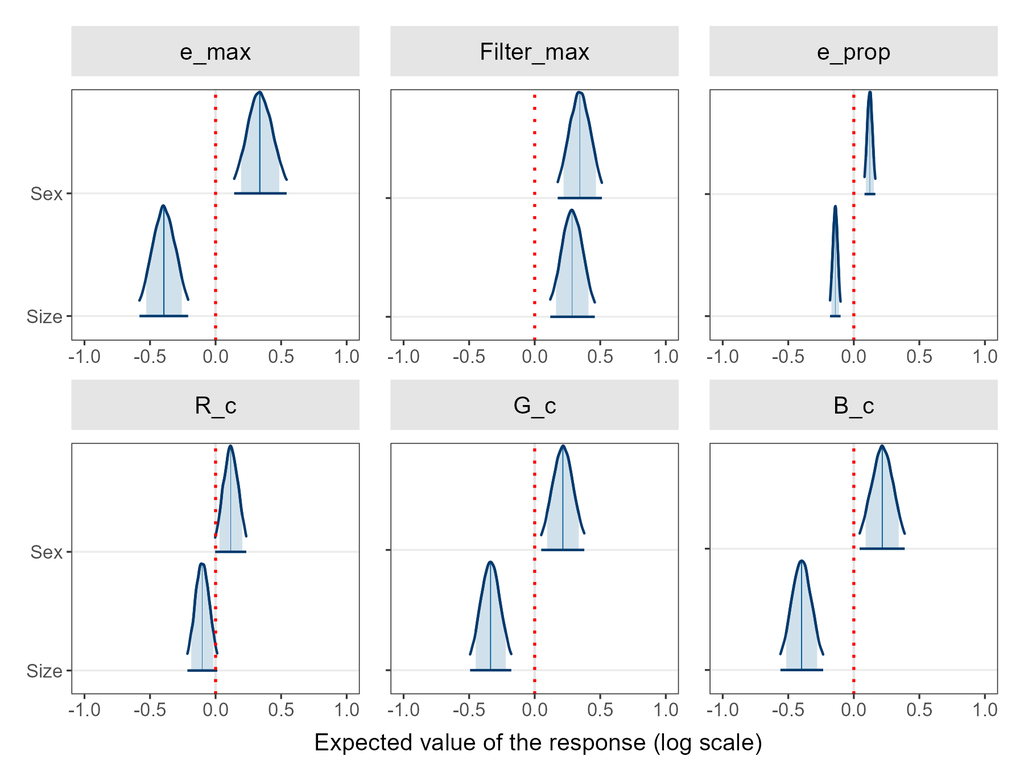

```r
# Convert images to base64
plot_posteriors_m4 <- knitr::image_uri("C:/Users/bmc82/Documents/UF/PhD_Projects/DISSERTATION_MANUSCRIPT/Chapter_3/chapter3_data_analysis/images/plot_posteriors_m4.png")


# Create the HTML
html_posteriors <- paste0("
  <style>
    .image-row {
      display: flex;
      gap: 20px;
      justify-content: center;
      align-items: flex-start;
    }
    .image-row img {
      max-width: 100%;
      height: auto;
      border: 1px solid #ccc;
    }
  </style>

  <img src='", plot_posteriors_m4, "' alt='Posterior Plot'>

")


# Display the HTML
IRdisplay::display_html(html_posteriors)
```

The graph of the posteriors gives us an idea of the significance of each predictor. We need to follow up with an evaluation of the model performance before we can trust these results.

### 7. Evaluate model performance

#### **Trace plots**

Visualize parameter sampling across iterations to confirm convergence. Each chain should wander around the same mean value without any strong upward or downward trends. “fuzzy caterpillar” or “horizontal band.”

**Show code cell content Hide code cell content**

```r
# Generate trace plots for all models
trace_plots_m4v1_e_max <- generate_trace_plot(
  model = m4v1_e_max,
  regex_pars = c("b_Size_center", "b_SexF"),
  plot_title = NULL,
  axis_title_y = TRUE,
  axis_text_x = TRUE,
  axis_title_size = 10,  # Increase axis title size
  axis_text_size = 8    # Increase axis tick label size
)

trace_plots_m4v1_Filter_max <- generate_trace_plot(
  model = m4v1_Filter_max,
  regex_pars = c("b_Size_center", "b_SexF"),
  plot_title = NULL,
  axis_title_y = TRUE,
  axis_text_x = TRUE,
  axis_title_size = 10,  # Increase axis title size
  axis_text_size = 8    # Increase axis tick label size
)

trace_plots_m4v1_e_prop <- generate_trace_plot(
  model = m4v1_e_prop,
  regex_pars = c("b_Size_center", "b_SexF"),
  plot_title = NULL,
  axis_title_y = TRUE,
  axis_text_x = TRUE,
  axis_title_size = 10,  # Increase axis title size
  axis_text_size = 8    # Increase axis tick label size
)

trace_plots_m4v1_R_c <- generate_trace_plot(
  model = m4v1_R_c,
  regex_pars = c("b_Size_center", "b_SexF"),
  plot_title = NULL,
  axis_title_y = TRUE,
  axis_text_x = TRUE,
  axis_title_size = 10,  # Increase axis title size
  axis_text_size = 8    # Increase axis tick label size
)

trace_plots_m4v1_G_c <- generate_trace_plot(
  model = m4v1_G_c,
  regex_pars = c("b_Size_center", "b_SexF"),
  plot_title = NULL,
  axis_title_y = TRUE,
  axis_text_x = TRUE,
  axis_title_size = 10,  # Increase axis title size
  axis_text_size = 8    # Increase axis tick label size
)

trace_plots_m4v1_B_c <- generate_trace_plot(
  model = m4v1_B_c,
  regex_pars = c("b_Size_center", "b_SexF"),
  plot_title = NULL,
  axis_title_y = TRUE,
  axis_text_x = TRUE,
  axis_title_size = 10,  # Increase axis title size
  axis_text_size = 8    # Increase axis tick label size
)


ggsave("C:/Users/bmc82/Documents/UF/PhD_Projects/DISSERTATION_MANUSCRIPT/Chapter_3/chapter3_data_analysis/images/trace_plots_m4v1_e_max.png", plot = trace_plots_m4v1_e_max, width = 6, height = 3, units = "in", dpi = 300)
ggsave("C:/Users/bmc82/Documents/UF/PhD_Projects/DISSERTATION_MANUSCRIPT/Chapter_3/chapter3_data_analysis/images/trace_plots_m4v1_Filter_max.png", plot = trace_plots_m4v1_Filter_max, width = 6, height = 3, units = "in", dpi = 300)
ggsave("C:/Users/bmc82/Documents/UF/PhD_Projects/DISSERTATION_MANUSCRIPT/Chapter_3/chapter3_data_analysis/images/trace_plots_m4v1_e_prop.png", plot = trace_plots_m4v1_e_prop, width = 6, height = 3, units = "in", dpi = 300)
ggsave("C:/Users/bmc82/Documents/UF/PhD_Projects/DISSERTATION_MANUSCRIPT/Chapter_3/chapter3_data_analysis/images/trace_plots_m4v1_R_c.png", plot = trace_plots_m4v1_R_c, width = 6, height = 3, units = "in", dpi = 300)
ggsave("C:/Users/bmc82/Documents/UF/PhD_Projects/DISSERTATION_MANUSCRIPT/Chapter_3/chapter3_data_analysis/images/trace_plots_m4v1_G_c.png", plot = trace_plots_m4v1_G_c, width = 6, height = 3, units = "in", dpi = 300)
ggsave("C:/Users/bmc82/Documents/UF/PhD_Projects/DISSERTATION_MANUSCRIPT/Chapter_3/chapter3_data_analysis/images/trace_plots_m4v1_B_c.png", plot = trace_plots_m4v1_B_c, width = 6, height = 3, units = "in", dpi = 300)
```

**Show code cell source Hide code cell source**

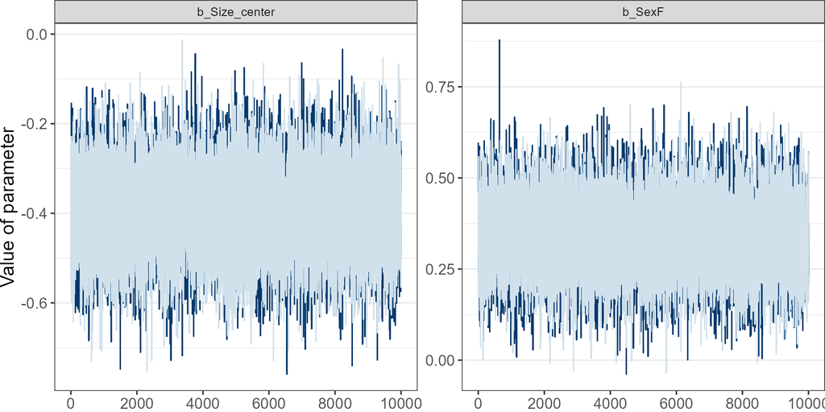

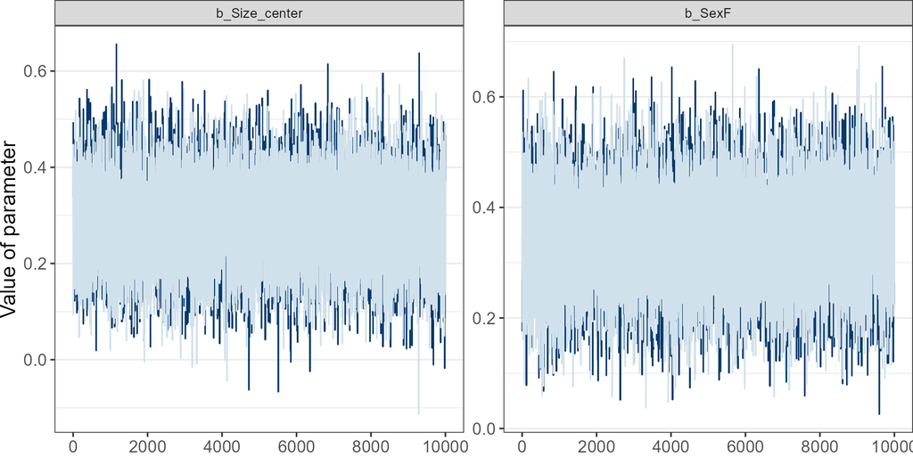

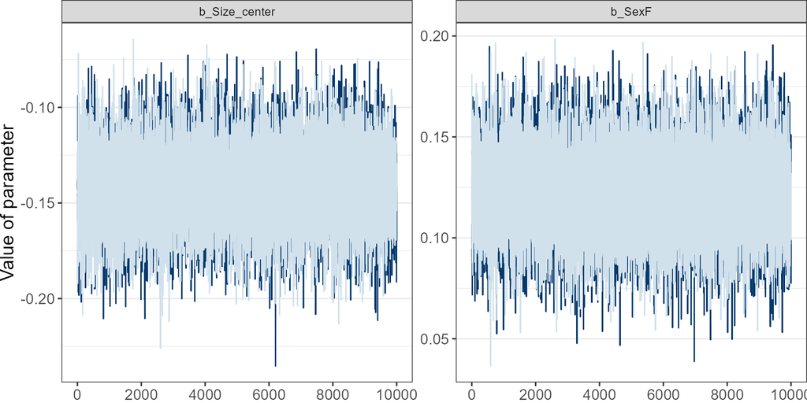

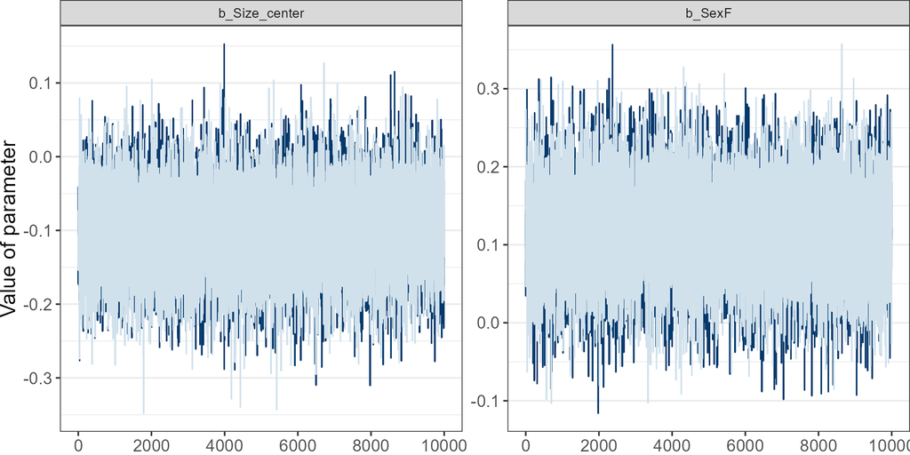

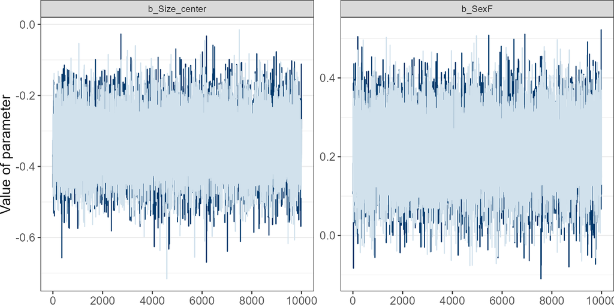

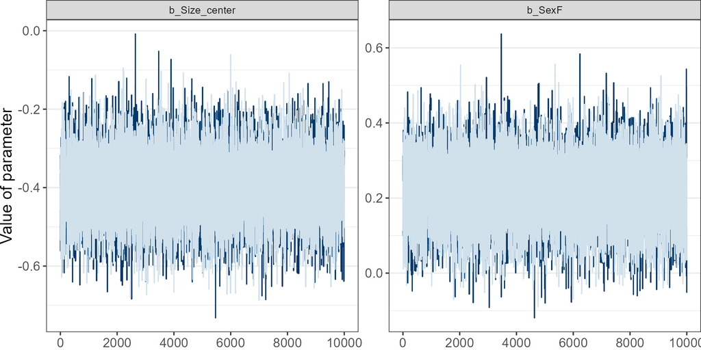

```r
# Convert images to base64 (if not already done)
trace_plots_m4v1_e_max <- knitr::image_uri("C:/Users/bmc82/Documents/UF/PhD_Projects/DISSERTATION_MANUSCRIPT/Chapter_3/chapter3_data_analysis/images/trace_plots_m4v1_e_max.png")
trace_plots_m4v1_Filter_max <- knitr::image_uri("C:/Users/bmc82/Documents/UF/PhD_Projects/DISSERTATION_MANUSCRIPT/Chapter_3/chapter3_data_analysis/images/trace_plots_m4v1_Filter_max.png")
trace_plots_m4v1_e_prop <- knitr::image_uri("C:/Users/bmc82/Documents/UF/PhD_Projects/DISSERTATION_MANUSCRIPT/Chapter_3/chapter3_data_analysis/images/trace_plots_m4v1_e_prop.png")
trace_plots_m4v1_R_c <- knitr::image_uri("C:/Users/bmc82/Documents/UF/PhD_Projects/DISSERTATION_MANUSCRIPT/Chapter_3/chapter3_data_analysis/images/trace_plots_m4v1_R_c.png")
trace_plots_m4v1_G_c <- knitr::image_uri("C:/Users/bmc82/Documents/UF/PhD_Projects/DISSERTATION_MANUSCRIPT/Chapter_3/chapter3_data_analysis/images/trace_plots_m4v1_G_c.png")
trace_plots_m4v1_B_c <- knitr::image_uri("C:/Users/bmc82/Documents/UF/PhD_Projects/DISSERTATION_MANUSCRIPT/Chapter_3/chapter3_data_analysis/images/trace_plots_m4v1_B_c.png")


# Create the HTML (horizontal + vertical display)
html_trace_plots <- paste0("
<style>
  .grid-container {
    display: grid;
    grid-template-columns: repeat(2, 1fr); /* 2 columns per row */
    gap: 3px;
    padding: 3px;
    justify-items: center;
  }

  .grid-container img {
    max-width: 600px;
    width: 100%;
    height: auto;
    border: 1px solid #ccc;
  }
</style>

<div class='grid-container'>
  <img src='", trace_plots_m4v1_e_max, "' alt='e_max Plot'>
  <img src='", trace_plots_m4v1_Filter_max, "' alt='Filter_max Plot'>
  <img src='", trace_plots_m4v1_e_prop, "' alt='e_prop Plot'>
  <img src='", trace_plots_m4v1_R_c, "' alt='R Reflectance Plot'>
  <img src='", trace_plots_m4v1_G_c, "' alt='G Reflectance Plot'>
  <img src='", trace_plots_m4v1_B_c, "' alt='B Reflectance Plot'>
</div>
")

IRdisplay::display_html(html_trace_plots)
```

#### **Posterior predictive checks**

Simulate data based on the models and compare to observed data to verify goodness-of-fit. We do this using “pp_check”. The observed data (black line/dots) should sit comfortably within the distribution of simulated data (colored areas or lines)

**Show code cell content Hide code cell content**

```r
# Generate posterior predictive check plots for all models
pp_check_plots_m4v1_e_max <-  generate_pp_check(
  model = m4v1_e_max,
  nreps = 100,
  axis_title_y = TRUE,
  y_label = "Density",
  plot_title = "e_max Model",
  axis_title_size = 10,  # custom title size
  axis_text_size = 8    # custom tick label size
)

pp_check_plots_m4v1_Filter_max <-  generate_pp_check(
  model = m4v1_Filter_max,
  nreps = 100,
  axis_title_y = TRUE,
  y_label = "Density",
  plot_title = "Filter_max Model",
  axis_title_size = 10,  # custom title size
  axis_text_size = 8    # custom tick label size
)

# Generate posterior predictive check plots for all models
pp_check_plots_m4v1_e_prop <-  generate_pp_check(
  model = m4v1_e_prop,
  nreps = 100,
  axis_title_y = TRUE,
  y_label = "Density",
  plot_title = "e_prop Model",
  axis_title_size = 10,  # custom title size
  axis_text_size = 8    # custom tick label size
)

pp_check_plots_m4v1_R_c <-  generate_pp_check(
  model = m4v1_R_c,
  nreps = 100,
  axis_title_y = TRUE,
  y_label = "Density",
  plot_title = "R Reflectance Model",
  axis_title_size = 10,  # custom title size
  axis_text_size = 8    # custom tick label size
)

# Generate posterior predictive check plots for all models
pp_check_plots_m4v1_G_c <-  generate_pp_check(
  model = m4v1_G_c,
  nreps = 100,
  axis_title_y = TRUE,
  y_label = "Density",
  plot_title = "G Reflectance Model",
  axis_title_size = 10,  # custom title size
  axis_text_size = 8    # custom tick label size
)

pp_check_plots_m4v1_B_c <-  generate_pp_check(
  model = m4v1_B_c,
  nreps = 100,
  axis_title_y = TRUE,
  y_label = "Density",
  plot_title = "B Reflectance Model",
  axis_title_size = 10,  # custom title size
  axis_text_size = 8    # custom tick label size
)

ggsave("C:/Users/bmc82/Documents/UF/PhD_Projects/DISSERTATION_MANUSCRIPT/Chapter_3/chapter3_data_analysis/images/pp_check_plots_m4v1_e_max.png", plot = pp_check_plots_m4v1_e_max, width = 3, height = 3, units = "in", dpi = 300)

ggsave("C:/Users/bmc82/Documents/UF/PhD_Projects/DISSERTATION_MANUSCRIPT/Chapter_3/chapter3_data_analysis/images/pp_check_plots_m4v1_Filter_max.png", plot = pp_check_plots_m4v1_Filter_max, width = 3, height = 3, units = "in", dpi = 300)

ggsave("C:/Users/bmc82/Documents/UF/PhD_Projects/DISSERTATION_MANUSCRIPT/Chapter_3/chapter3_data_analysis/images/pp_check_plots_m4v1_e_prop.png", plot = pp_check_plots_m4v1_e_prop, width = 3, height = 3, units = "in", dpi = 300)

ggsave("C:/Users/bmc82/Documents/UF/PhD_Projects/DISSERTATION_MANUSCRIPT/Chapter_3/chapter3_data_analysis/images/pp_check_plots_m4v1_R_c.png", plot = pp_check_plots_m4v1_R_c, width = 3, height = 3, units = "in", dpi = 300)

ggsave("C:/Users/bmc82/Documents/UF/PhD_Projects/DISSERTATION_MANUSCRIPT/Chapter_3/chapter3_data_analysis/images/pp_check_plots_m4v1_G_c.png", plot = pp_check_plots_m4v1_G_c, width = 3, height = 3, units = "in", dpi = 300)

ggsave("C:/Users/bmc82/Documents/UF/PhD_Projects/DISSERTATION_MANUSCRIPT/Chapter_3/chapter3_data_analysis/images/pp_check_plots_m4v1_B_c.png", plot = pp_check_plots_m4v1_B_c, width = 3, height = 3, units = "in", dpi = 300)
```

[output not shown]

[output not shown]

[output not shown]

[output not shown]

[output not shown]

[output not shown]

[output not shown]

[output not shown]

[output not shown]

[output not shown]

[output not shown]

[output not shown]

[output not shown]

[output not shown]

[output not shown]

[output not shown]

[output not shown]

[output not shown]

**Show code cell source Hide code cell source**

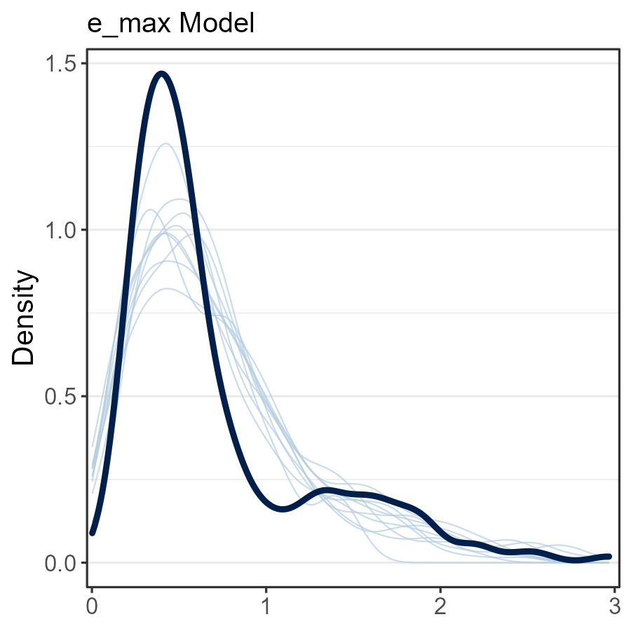

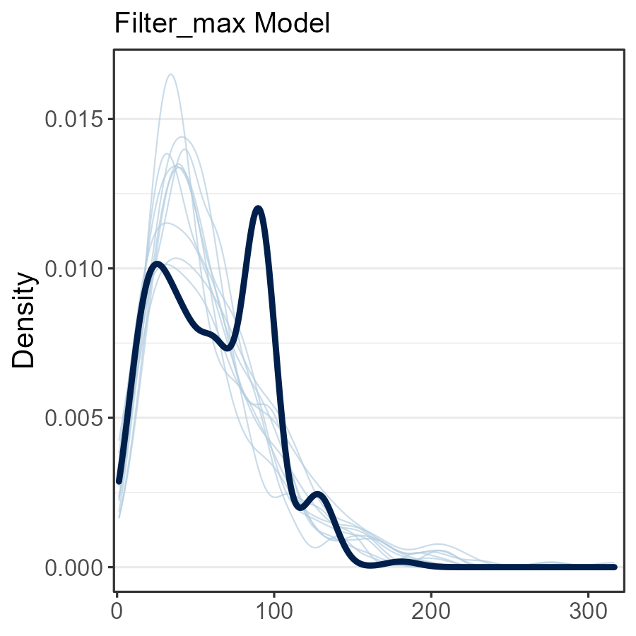

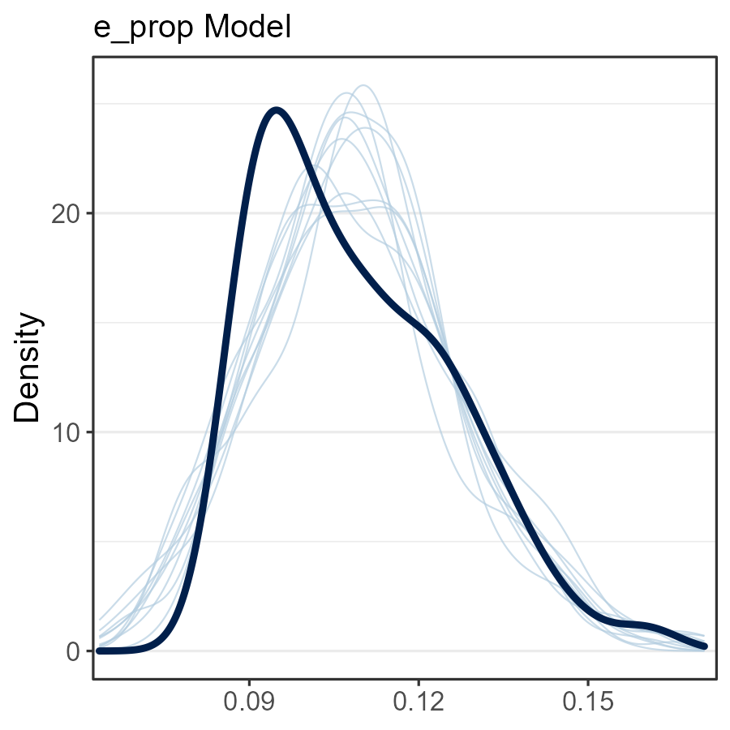

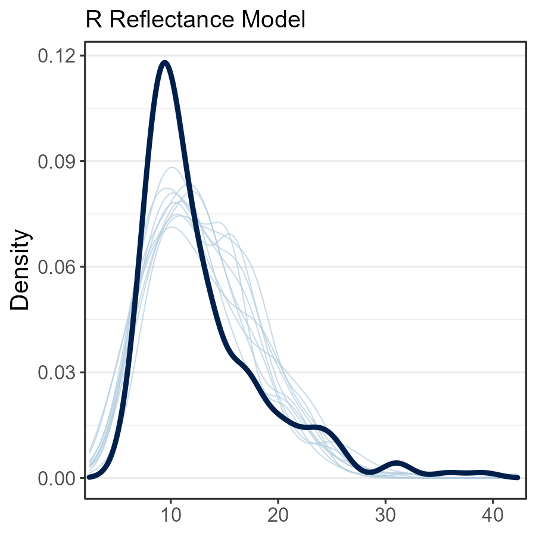

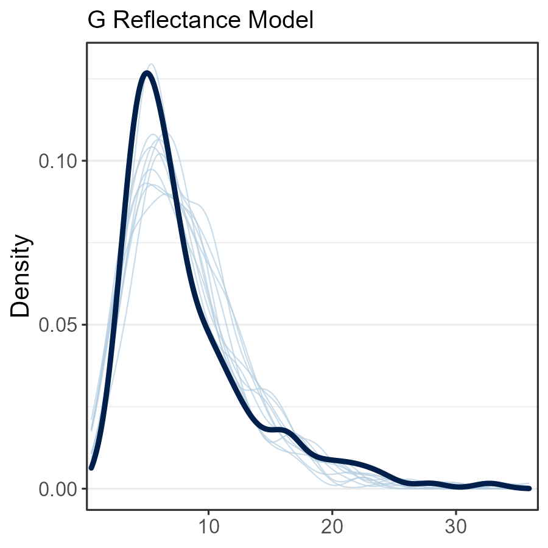

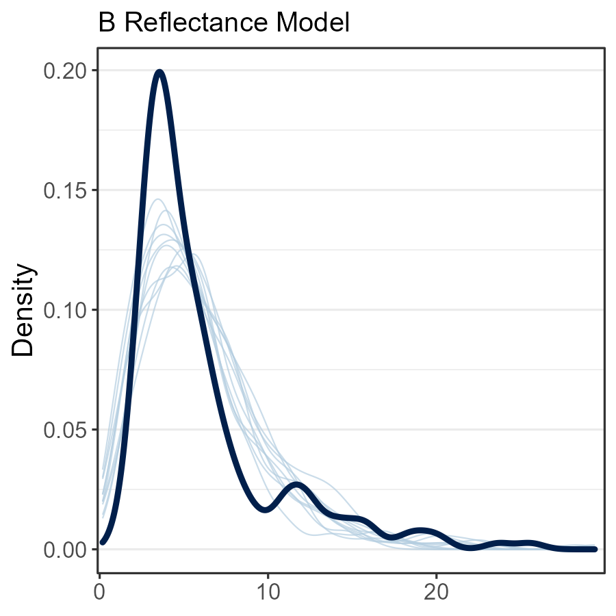

```r
# Convert images to base64
pp_check_plots_m4v1_e_max <- knitr::image_uri("C:/Users/bmc82/Documents/UF/PhD_Projects/DISSERTATION_MANUSCRIPT/Chapter_3/chapter3_data_analysis/images/pp_check_plots_m4v1_e_max.png")
pp_check_plots_m4v1_Filter_max     <- knitr::image_uri("C:/Users/bmc82/Documents/UF/PhD_Projects/DISSERTATION_MANUSCRIPT/Chapter_3/chapter3_data_analysis/images/pp_check_plots_m4v1_Filter_max.png")
pp_check_plots_m4v1_e_prop    <- knitr::image_uri("C:/Users/bmc82/Documents/UF/PhD_Projects/DISSERTATION_MANUSCRIPT/Chapter_3/chapter3_data_analysis/images/pp_check_plots_m4v1_e_prop.png")
pp_check_plots_m4v1_R_c <- knitr::image_uri("C:/Users/bmc82/Documents/UF/PhD_Projects/DISSERTATION_MANUSCRIPT/Chapter_3/chapter3_data_analysis/images/pp_check_plots_m4v1_R_c.png")
pp_check_plots_m4v1_G_c     <- knitr::image_uri("C:/Users/bmc82/Documents/UF/PhD_Projects/DISSERTATION_MANUSCRIPT/Chapter_3/chapter3_data_analysis/images/pp_check_plots_m4v1_G_c.png")
pp_check_plots_m4v1_B_c    <- knitr::image_uri("C:/Users/bmc82/Documents/UF/PhD_Projects/DISSERTATION_MANUSCRIPT/Chapter_3/chapter3_data_analysis/images/pp_check_plots_m4v1_B_c.png")


# HTML & CSS grid layout
html_pp_check_plots <- paste0("
<style>
  .grid-container {
    display: grid;
    grid-template-columns: repeat(3, 1fr); /* 3 columns per row */
    gap: 15px;
    padding: 10px;
    justify-items: center;
  }

  .grid-container img {
    max-width: 300px;
    width: 100%;
    height: auto;
    border: 1px solid #ccc;
  }
</style>

<div class='grid-container'>
  <img src='", pp_check_plots_m4v1_e_max, "' alt='e_max Plot'>
  <img src='", pp_check_plots_m4v1_Filter_max, "' alt='Filter_max Plot'>
  <img src='", pp_check_plots_m4v1_e_prop, "' alt='e_prop Plot'>
  <img src='", pp_check_plots_m4v1_R_c, "' alt='R Reflectance Plot'>
  <img src='", pp_check_plots_m4v1_G_c, "' alt='G Reflectance Plot'>
  <img src='", pp_check_plots_m4v1_B_c, "' alt='B Reflectance Plot'>
</div>
")

IRdisplay::display_html(html_pp_check_plots)
```

#### **Check convergence**

Check that all $\hat{R}$ values are close to 1, indicating good convergence.

```r
# Create a helper function
extract_rhat <- function(model, model_name) {
  rhat(model) %>%
    as.data.frame() %>%
    rownames_to_column(var = "Parameter") %>%
    dplyr::filter(startsWith(Parameter, "b_")) %>%   # <-- keep only b_ terms
    dplyr::rename(Rhat = 2) %>%
    dplyr::mutate(Model = model_name) %>%
    dplyr::mutate(across(where(is.numeric), ~ signif(.x, digits = 3)))
}

# Extract for each model group
rhat1 <- extract_rhat(m4v1_e_max,   "e_max")
rhat2 <- extract_rhat(m4v1_Filter_max,    "Filter_max")
rhat3 <- extract_rhat(m4v1_e_prop,  "e_prop")
rhat4 <- extract_rhat(m4v1_R_c,          "R_c")
rhat5 <- extract_rhat(m4v1_G_c,          "G_c")
rhat6 <- extract_rhat(m4v1_B_c,          "B_c")
```

**Show code cell content Hide code cell content**

```r
# Save tables
write.table(rhat1, "C:/Users/bmc82/Documents/UF/PhD_Projects/DISSERTATION_MANUSCRIPT/Chapter_3/chapter3_data_analysis/data/tables/table_rhat_m4v1_e_max.csv", sep = ",", row.names = FALSE, col.names = TRUE)
write.table(rhat2, "C:/Users/bmc82/Documents/UF/PhD_Projects/DISSERTATION_MANUSCRIPT/Chapter_3/chapter3_data_analysis/data/tables/table_rhat_m4v1_Filter_max.csv", sep = ",", row.names = FALSE, col.names = TRUE)
write.table(rhat3, "C:/Users/bmc82/Documents/UF/PhD_Projects/DISSERTATION_MANUSCRIPT/Chapter_3/chapter3_data_analysis/data/tables/table_rhat_m4v1_e_prop.csv", sep = ",", row.names = FALSE, col.names = TRUE)
write.table(rhat4, "C:/Users/bmc82/Documents/UF/PhD_Projects/DISSERTATION_MANUSCRIPT/Chapter_3/chapter3_data_analysis/data/tables/table_rhat_m4v1_R_c.csv", sep = ",", row.names = FALSE, col.names = TRUE)
write.table(rhat5, "C:/Users/bmc82/Documents/UF/PhD_Projects/DISSERTATION_MANUSCRIPT/Chapter_3/chapter3_data_analysis/data/tables/table_rhat_m4v1_G_c.csv", sep = ",", row.names = FALSE, col.names = TRUE)
write.table(rhat6, "C:/Users/bmc82/Documents/UF/PhD_Projects/DISSERTATION_MANUSCRIPT/Chapter_3/chapter3_data_analysis/data/tables/table_rhat_m4v1_B_c.csv", sep = ",", row.names = FALSE, col.names = TRUE)
```

**Show code cell source Hide code cell source**

```r
# Convert each data frame to a plain HTML table string
table_1_rhat <- minimal_html_table(rhat1, caption = "Rhat values - e_max")
table_2_rhat <- minimal_html_table(rhat2, caption = "Rhat values - Filter_max")
table_3_rhat <- minimal_html_table(rhat3, caption = "Rhat values - e_prop")
table_4_rhat <- minimal_html_table(rhat4, caption = "Rhat values - R")
table_5_rhat <- minimal_html_table(rhat5, caption = "Rhat values - G")
table_6_rhat <- minimal_html_table(rhat6, caption = "Rhat values - B")


my_tabs_rhat <- '
<style>
/* Basic container styling */
.tabs-container {
  width: 100%;
  margin: 1em 0;
}

/* Hide the radio inputs (we only show their labels as tabs) */
.tabs-container input[type="radio"] {
  display: none;
}

/* The “tab-label” styling: looks like a tab */
.tab-label {
  display: inline-block;
  padding: 10px;
  margin-right: 2px;
  background: #eee;
  border: 1px solid #ccc;
  cursor: pointer;
  border-bottom: none;
}

/* The active tab label */
.tab-label-active {
  background: #fff;
}

/* The panel that holds table content */
.tab-content {
  border: 1px solid #ccc;
  padding: 10px;
  display: none;
}

/* For each radio input, show its corresponding content when checked */
#tab1_rhat:checked ~ #content1_rhat,
#tab2_rhat:checked ~ #content2_rhat,
#tab3_rhat:checked ~ #content3_rhat,
#tab4_rhat:checked ~ #content4_rhat,
#tab5_rhat:checked ~ #content5_rhat,
#tab6_rhat:checked ~ #content6_rhat {
  display: block;
}

/* Also style the label of the checked radio as “active” using the :checked + label technique */
#tab1_rhat:checked + label[for="tab1_rhat"],
#tab2_rhat:checked + label[for="tab2_rhat"],
#tab3_rhat:checked + label[for="tab3_rhat"],
#tab4_rhat:checked + label[for="tab4_rhat"],
#tab5_rhat:checked + label[for="tab5_rhat"],
#tab6_rhat:checked + label[for="tab6_rhat"] {
  background: #fff;
  border-bottom: none;
}
</style>

<div class="tabs-container">

  <!-- 1) Tab radio + label -->
  <input type="radio" name="tabs_rhat" id="tab1_rhat" checked>
  <label class="tab-label" for="tab1_rhat">Table 1</label>

  <!-- 2) Tab radio + label -->
  <input type="radio" name="tabs_rhat" id="tab2_rhat">
  <label class="tab-label" for="tab2_rhat">Table 2</label>

  <!-- 3) Tab radio + label -->
  <input type="radio" name="tabs_rhat" id="tab3_rhat">
  <label class="tab-label" for="tab3_rhat">Table 3</label>

  <!-- 4) Tab radio + label -->
  <input type="radio" name="tabs_rhat" id="tab4_rhat">
  <label class="tab-label" for="tab4_rhat">Table 4</label>

  <!-- 5) Tab radio + label -->
  <input type="radio" name="tabs_rhat" id="tab5_rhat">
  <label class="tab-label" for="tab5_rhat">Table 5</label>

  <!-- 6) Tab radio + label -->
  <input type="radio" name="tabs_rhat" id="tab6_rhat">
  <label class="tab-label" for="tab6_rhat">Table 6</label>

  <!-- Content for each tab -->
  <div class="tab-content" id="content1_rhat">REPLACE_WITH_table_1</div>
  <div class="tab-content" id="content2_rhat">REPLACE_WITH_table_2</div>
  <div class="tab-content" id="content3_rhat">REPLACE_WITH_table_3</div>
  <div class="tab-content" id="content4_rhat">REPLACE_WITH_table_4</div>
  <div class="tab-content" id="content5_rhat">REPLACE_WITH_table_5</div>
  <div class="tab-content" id="content6_rhat">REPLACE_WITH_table_6</div>
</div>
'

# Now do the replacements for each table
my_tabs_rhat <- gsub("REPLACE_WITH_table_1", table_1_rhat, my_tabs_rhat)
my_tabs_rhat <- gsub("REPLACE_WITH_table_2", table_2_rhat, my_tabs_rhat)
my_tabs_rhat <- gsub("REPLACE_WITH_table_3", table_3_rhat, my_tabs_rhat)
my_tabs_rhat <- gsub("REPLACE_WITH_table_4", table_4_rhat, my_tabs_rhat)
my_tabs_rhat <- gsub("REPLACE_WITH_table_5", table_5_rhat, my_tabs_rhat)
my_tabs_rhat <- gsub("REPLACE_WITH_table_6", table_6_rhat, my_tabs_rhat)

IRdisplay::display_html(my_tabs_rhat)
```

Table 1 Table 2 Table 3 Table 4 Table 5 Table 6

Rhat values - e_max

| Parameter | Rhat | Model |
| --- | --- | --- |
| b_Intercept | 1 | e_max |
| b_Size_center | 1 | e_max |
| b_SexF | 1 | e_max |

Rhat values - Filter_max

| Parameter | Rhat | Model |
| --- | --- | --- |
| b_Intercept | 1 | Filter_max |
| b_Size_center | 1 | Filter_max |
| b_SexF | 1 | Filter_max |

Rhat values - e_prop

| Parameter | Rhat | Model |
| --- | --- | --- |
| b_Intercept | 1 | e_prop |
| b_Size_center | 1 | e_prop |
| b_SexF | 1 | e_prop |

Rhat values - R

| Parameter | Rhat | Model |
| --- | --- | --- |
| b_Intercept | 1 | R_c |
| b_Size_center | 1 | R_c |
| b_SexF | 1 | R_c |

Rhat values - G

| Parameter | Rhat | Model |
| --- | --- | --- |
| b_Intercept | 1 | G_c |
| b_Size_center | 1 | G_c |
| b_SexF | 1 | G_c |

Rhat values - B

| Parameter | Rhat | Model |
| --- | --- | --- |
| b_Intercept | 1 | B_c |
| b_Size_center | 1 | B_c |
| b_SexF | 1 | B_c |

#### **Check uncertainty**

Extract parameter estimates and their confidence intervals to assess the significance of the predictors on color pattern metrics. We check 85% and 95% confidence intervals. Summaries are displayed in tables for all models.

```r
# Extract summaries for each variable
extract_summary <- function(model, prob_85, prob_95) {
    summary_85 <- summary(model, prob = prob_85)
    summary_95 <- summary(model, prob = prob_95)

    as.data.frame(summary_85$fixed) %>%
        dplyr::select("Estimate", "Est.Error", "l-85% CI", "u-85% CI") %>%
        mutate(
            "l-95% CI" = summary_95$fixed$`l-95% CI`,
            "u-95% CI" = summary_95$fixed$`u-95% CI`
        ) %>%
        mutate(across(where(is.numeric), ~ signif(.x, digits = 3))) %>%
        rownames_to_column(var = "Parameter") # Add rownames as Parameter column
}

uncertainty1 <- extract_summary(m4v1_e_max, prob_85 = 0.85, prob_95 = 0.95)
uncertainty2 <- extract_summary(m4v1_Filter_max, prob_85 = 0.85, prob_95 = 0.95)
uncertainty3 <- extract_summary(m4v1_e_prop, prob_85 = 0.85, prob_95 = 0.95)
uncertainty4 <- extract_summary(m4v1_R_c, prob_85 = 0.85, prob_95 = 0.95)
uncertainty5 <- extract_summary(m4v1_G_c, prob_85 = 0.85, prob_95 = 0.95)
uncertainty6 <- extract_summary(m4v1_B_c, prob_85 = 0.85, prob_95 = 0.95)
```

**Show code cell content Hide code cell content**

```r
# Save tables
write.table(uncertainty1, "C:/Users/bmc82/Documents/UF/PhD_Projects/DISSERTATION_MANUSCRIPT/Chapter_3/chapter3_data_analysis/data/tables/table_uncertainty_m4v1_e_max.csv", sep = ",", row.names = TRUE, col.names = TRUE)

write.table(uncertainty2, "C:/Users/bmc82/Documents/UF/PhD_Projects/DISSERTATION_MANUSCRIPT/Chapter_3/chapter3_data_analysis/data/tables/table_uncertainty_m4v1_Filter_max.csv", sep = ",", row.names = TRUE, col.names = TRUE)

write.table(uncertainty3, "C:/Users/bmc82/Documents/UF/PhD_Projects/DISSERTATION_MANUSCRIPT/Chapter_3/chapter3_data_analysis/data/tables/table_uncertainty_m4v1_e_prop.csv", sep = ",", row.names = TRUE, col.names = TRUE)

write.table(uncertainty4, "C:/Users/bmc82/Documents/UF/PhD_Projects/DISSERTATION_MANUSCRIPT/Chapter_3/chapter3_data_analysis/data/tables/table_uncertainty_m4v1_R_c.csv", sep = ",", row.names = TRUE, col.names = TRUE)

write.table(uncertainty5, "C:/Users/bmc82/Documents/UF/PhD_Projects/DISSERTATION_MANUSCRIPT/Chapter_3/chapter3_data_analysis/data/tables/table_uncertainty_m4v1_G_c.csv", sep = ",", row.names = TRUE, col.names = TRUE)

write.table(uncertainty6, "C:/Users/bmc82/Documents/UF/PhD_Projects/DISSERTATION_MANUSCRIPT/Chapter_3/chapter3_data_analysis/data/tables/table_uncertainty_m4v1_B_c.csv", sep = ",", row.names = TRUE, col.names = TRUE)
```

**Show code cell source Hide code cell source**

```r
# Convert each data frame to a plain HTML table string
table_1_uncertainty <- minimal_html_table(uncertainty1, caption = "Uncertainty values - e_max")
table_2_uncertainty <- minimal_html_table(uncertainty2, caption = "Uncertainty values - Filter_max")
table_3_uncertainty <- minimal_html_table(uncertainty3, caption = "Uncertainty values - e_prop")
table_4_uncertainty <- minimal_html_table(uncertainty4, caption = "Uncertainty values - R")
table_5_uncertainty <- minimal_html_table(uncertainty5, caption = "Uncertainty values - G")
table_6_uncertainty <- minimal_html_table(uncertainty6, caption = "Uncertainty values - B")


my_tabs_uncertainty <- '
<style>
/* Basic container styling */
.tabs-container {
  width: 100%;
  margin: 1em 0;
}

/* Hide the radio inputs (we only show their labels as tabs) */
.tabs-container input[type="radio"] {
  display: none;
}

/* The “tab-label” styling: looks like a tab */
.tab-label {
  display: inline-block;
  padding: 10px;
  margin-right: 2px;
  background: #eee;
  border: 1px solid #ccc;
  cursor: pointer;
  border-bottom: none;
}

/* The active tab label */
.tab-label-active {
  background: #fff;
}

/* The panel that holds table content */
.tab-content {
  border: 1px solid #ccc;
  padding: 10px;
  display: none;
}

/* For each radio input, show its corresponding content when checked */
#tab1_uncertainty:checked ~ #content1_uncertainty,
#tab2_uncertainty:checked ~ #content2_uncertainty,
#tab3_uncertainty:checked ~ #content3_uncertainty,
#tab4_uncertainty:checked ~ #content4_uncertainty,
#tab5_uncertainty:checked ~ #content5_uncertainty,
#tab6_uncertainty:checked ~ #content6_uncertainty {
  display: block;
}

/* Also style the label of the checked radio as “active” using the :checked + label technique */
#tab1_uncertainty:checked + label[for="tab1_uncertainty"],
#tab2_uncertainty:checked + label[for="tab2_uncertainty"],
#tab3_uncertainty:checked + label[for="tab3_uncertainty"],
#tab4_uncertainty:checked + label[for="tab4_uncertainty"],
#tab5_uncertainty:checked + label[for="tab5_uncertainty"],
#tab6_uncertainty:checked + label[for="tab6_uncertainty"] {
  background: #fff;
  border-bottom: none;
}
</style>

<div class="tabs-container">

  <!-- 1) Tab radio + label -->
  <input type="radio" name="tabs_uncertainty" id="tab1_uncertainty" checked>
  <label class="tab-label" for="tab1_uncertainty">Table 1</label>

  <!-- 2) Tab radio + label -->
  <input type="radio" name="tabs_uncertainty" id="tab2_uncertainty">
  <label class="tab-label" for="tab2_uncertainty">Table 2</label>

  <!-- 3) Tab radio + label -->
  <input type="radio" name="tabs_uncertainty" id="tab3_uncertainty">
  <label class="tab-label" for="tab3_uncertainty">Table 3</label>

  <!-- 4) Tab radio + label -->
  <input type="radio" name="tabs_uncertainty" id="tab4_uncertainty">
  <label class="tab-label" for="tab4_uncertainty">Table 4</label>

  <!-- 5) Tab radio + label -->
  <input type="radio" name="tabs_uncertainty" id="tab5_uncertainty">
  <label class="tab-label" for="tab5_uncertainty">Table 5</label>

  <!-- 6) Tab radio + label -->
  <input type="radio" name="tabs_uncertainty" id="tab6_uncertainty">
  <label class="tab-label" for="tab6_uncertainty">Table 6</label>

  <!-- Content for each tab -->
  <div class="tab-content" id="content1_uncertainty">REPLACE_WITH_table_1</div>
  <div class="tab-content" id="content2_uncertainty">REPLACE_WITH_table_2</div>
  <div class="tab-content" id="content3_uncertainty">REPLACE_WITH_table_3</div>
  <div class="tab-content" id="content4_uncertainty">REPLACE_WITH_table_4</div>
  <div class="tab-content" id="content5_uncertainty">REPLACE_WITH_table_5</div>
  <div class="tab-content" id="content6_uncertainty">REPLACE_WITH_table_6</div>
</div>
'

# Now do the replacements for each table
my_tabs_uncertainty <- gsub("REPLACE_WITH_table_1", table_1_uncertainty, my_tabs_uncertainty)
my_tabs_uncertainty <- gsub("REPLACE_WITH_table_2", table_2_uncertainty, my_tabs_uncertainty)
my_tabs_uncertainty <- gsub("REPLACE_WITH_table_3", table_3_uncertainty, my_tabs_uncertainty)
my_tabs_uncertainty <- gsub("REPLACE_WITH_table_4", table_4_uncertainty, my_tabs_uncertainty)
my_tabs_uncertainty <- gsub("REPLACE_WITH_table_5", table_5_uncertainty, my_tabs_uncertainty)
my_tabs_uncertainty <- gsub("REPLACE_WITH_table_6", table_6_uncertainty, my_tabs_uncertainty)

IRdisplay::display_html(my_tabs_uncertainty)
```

Table 1 Table 2 Table 3 Table 4 Table 5 Table 6

Uncertainty values - e_max

| Parameter | Estimate | Est.Error | l-85% CI | u-85% CI | l-95% CI | u-95% CI |
| --- | --- | --- | --- | --- | --- | --- |
| Intercept | -0.505 | 0.0631 | -0.595 | -0.414 | -0.628 | -0.38 |
| Size_center | -0.394 | 0.0949 | -0.529 | -0.257 | -0.581 | -0.209 |
| SexF | 0.339 | 0.102 | 0.194 | 0.486 | 0.142 | 0.542 |

Uncertainty values - Filter_max

| Parameter | Estimate | Est.Error | l-85% CI | u-85% CI | l-95% CI | u-95% CI |
| --- | --- | --- | --- | --- | --- | --- |
| Intercept | 3.94 | 0.0556 | 3.86 | 4.02 | 3.83 | 4.05 |
| Size_center | 0.287 | 0.0864 | 0.163 | 0.41 | 0.119 | 0.458 |
| SexF | 0.344 | 0.0863 | 0.22 | 0.468 | 0.176 | 0.513 |

Uncertainty values - e_prop

| Parameter | Estimate | Est.Error | l-85% CI | u-85% CI | l-95% CI | u-95% CI |
| --- | --- | --- | --- | --- | --- | --- |
| Intercept | -2.27 | 0.0132 | -2.29 | -2.25 | -2.3 | -2.25 |
| Size_center | -0.141 | 0.0204 | -0.171 | -0.112 | -0.181 | -0.101 |
| SexF | 0.122 | 0.0211 | 0.0919 | 0.153 | 0.0817 | 0.164 |

Uncertainty values - R

| Parameter | Estimate | Est.Error | l-85% CI | u-85% CI | l-95% CI | u-95% CI |
| --- | --- | --- | --- | --- | --- | --- |
| Intercept | 2.51 | 0.0377 | 2.45 | 2.56 | 2.43 | 2.58 |
| Size_center | -0.101 | 0.0583 | -0.186 | -0.0167 | -0.215 | 0.0126 |
| SexF | 0.116 | 0.0608 | 0.0295 | 0.204 | -0.00314 | 0.234 |

Uncertainty values - G

| Parameter | Estimate | Est.Error | l-85% CI | u-85% CI | l-95% CI | u-95% CI |
| --- | --- | --- | --- | --- | --- | --- |
| Intercept | 2 | 0.0527 | 1.92 | 2.08 | 1.9 | 2.1 |
| Size_center | -0.336 | 0.0797 | -0.45 | -0.221 | -0.493 | -0.178 |
| SexF | 0.215 | 0.0838 | 0.0946 | 0.336 | 0.0497 | 0.378 |

Uncertainty values - B

| Parameter | Estimate | Est.Error | l-85% CI | u-85% CI | l-95% CI | u-95% CI |
| --- | --- | --- | --- | --- | --- | --- |
| Intercept | 1.69 | 0.055 | 1.61 | 1.77 | 1.59 | 1.8 |
| Size_center | -0.398 | 0.0825 | -0.516 | -0.28 | -0.56 | -0.234 |
| SexF | 0.217 | 0.0879 | 0.09 | 0.343 | 0.0442 | 0.388 |

#### **Check posterior probabilities**

Now we can evaluate our hypotheses using the posterior distributions of the model parameters. Remember, we are concerned with two things:

1. Is there a difference between females and males? (Sex effect)
2. Is size associated with the color pattern metric? (Size effect)

We will calculate the posterior probability of these effects.

**Show code cell content Hide code cell content**

```r
##### **Posterior Probability of Size Effect**

draws_e_max <- as_draws_df(m4v1_e_max)
draws_Filter_max <- as_draws_df(m4v1_Filter_max)
draws_e_prop <- as_draws_df(m4v1_e_prop)
draws_R_c <- as_draws_df(m4v1_R_c)
draws_G_c <- as_draws_df(m4v1_G_c)
draws_B_c <- as_draws_df(m4v1_B_c)

# Posterior probability that females have a **higher** value than males
pp_size_e_max_positive <- mean(draws_e_max$b_Size_center > 0)
pp_size_Filter_max_positive <- mean(draws_Filter_max$b_Size_center > 0)
pp_size_e_prop_positive <- mean(draws_e_prop$b_Size_center > 0)
pp_size_R_c_positive <- mean(draws_R_c$b_Size_center > 0)
pp_size_G_c_positive <- mean(draws_G_c$b_Size_center > 0)
pp_size_B_c_positive <- mean(draws_B_c$b_Size_center > 0)

# Posterior probability that females have a **lower** value than males
pp_size_e_max_negative <- mean(draws_e_max$b_Size_center < 0)
pp_size_Filter_max_negative <- mean(draws_Filter_max$b_Size_center < 0)
pp_size_e_prop_negative <- mean(draws_e_prop$b_Size_center < 0)
pp_size_R_c_negative <- mean(draws_R_c$b_Size_center < 0)
pp_size_G_c_negative <- mean(draws_G_c$b_Size_center < 0)
pp_size_B_c_negative <- mean(draws_B_c$b_Size_center < 0)


# Create a summary table
pp_summary_m4_size <- data.frame(
  Hypothesis = c(
    "P(Size effect e_max > 0)",
    "P(Size effect e_max < 0)",
    "P(Size effect Filter_max > 0)",
    "P(Size effect Filter_max < 0)",
    "P(Size effect e_prop > 0)",
    "P(Size effect e_prop < 0)",
    "P(Size effect R_c > 0)",
    "P(Size effect R_c < 0)",
    "P(Size effect G_c > 0)",
    "P(Size effect G_c < 0)",
    "P(Size effect B_c > 0)",
    "P(Size effect B_c < 0)"
  ),
  PosteriorProbability = c(
    pp_size_e_max_positive,
    pp_size_e_max_negative,
    pp_size_Filter_max_positive,
    pp_size_Filter_max_negative,
    pp_size_e_prop_positive,
    pp_size_e_prop_negative,
    pp_size_R_c_positive,
    pp_size_R_c_negative,
    pp_size_G_c_positive,
    pp_size_G_c_negative,
    pp_size_B_c_positive,
    pp_size_B_c_negative
  )
)

# Save table
write.table(pp_summary_m4_size, "C:/Users/bmc82/Documents/UF/PhD_Projects/DISSERTATION_MANUSCRIPT/Chapter_3/chapter3_data_analysis/data/tables/table_postprob_m4v1_size.csv", sep = ",", row.names = TRUE, col.names = TRUE)
```

**Show code cell source Hide code cell source**

```r
# Generate HTML table
html_table <- minimal_html_table(pp_summary_m4_size, caption = "Posterior probabilities for Size Effect")

# Display it as HTML
IRdisplay::display_html(html_table)
```

Posterior probabilities for Size Effect

| Hypothesis | PosteriorProbability |
| --- | --- |
| P(Size effect e_max > 0) | 0 |
| P(Size effect e_max < 0) | 1 |
| P(Size effect Filter_max > 0) | 0.9993 |
| P(Size effect Filter_max < 0) | 7e-04 |
| P(Size effect e_prop > 0) | 0 |
| P(Size effect e_prop < 0) | 1 |
| P(Size effect R_c > 0) | 0.0418 |
| P(Size effect R_c < 0) | 0.9582 |
| P(Size effect G_c > 0) | 0 |
| P(Size effect G_c < 0) | 1 |
| P(Size effect B_c > 0) | 0 |
| P(Size effect B_c < 0) | 1 |

**Show code cell content Hide code cell content**

```r
##### **Posterior Probability of Sex Effect**

draws_e_max <- as_draws_df(m4v1_e_max)
draws_Filter_max <- as_draws_df(m4v1_Filter_max)
draws_e_prop <- as_draws_df(m4v1_e_prop)
draws_R_c <- as_draws_df(m4v1_R_c)
draws_G_c <- as_draws_df(m4v1_G_c)
draws_B_c <- as_draws_df(m4v1_B_c)

# Posterior probability that females have a **higher** value than males
pp_sex_e_max_positive <- mean(draws_e_max$b_SexF > 0)
pp_sex_Filter_max_positive <- mean(draws_Filter_max$b_SexF > 0)
pp_sex_e_prop_positive <- mean(draws_e_prop$b_SexF > 0)
pp_sex_R_c_positive <- mean(draws_R_c$b_SexF > 0)
pp_sex_G_c_positive <- mean(draws_G_c$b_SexF > 0)
pp_sex_B_c_positive <- mean(draws_B_c$b_SexF > 0)

# Posterior probability that females have a **lower** value than males
pp_sex_e_max_negative <- mean(draws_e_max$b_SexF < 0)
pp_sex_Filter_max_negative <- mean(draws_Filter_max$b_SexF < 0)
pp_sex_e_prop_negative <- mean(draws_e_prop$b_SexF < 0)
pp_sex_R_c_negative <- mean(draws_R_c$b_SexF < 0)
pp_sex_G_c_negative <- mean(draws_G_c$b_SexF < 0)
pp_sex_B_c_negative <- mean(draws_B_c$b_SexF < 0)


# Create a summary table
pp_summary_m4_sex <- data.frame(
  Hypothesis = c(
    "P(Sex effect e_max > 0)",
    "P(Sex effect e_max < 0)",
    "P(Sex effect Filter_max > 0)",
    "P(Sex effect Filter_max < 0)",
    "P(Sex effect e_prop > 0)",
    "P(Sex effect e_prop < 0)",
    "P(Sex effect R_c > 0)",
    "P(Sex effect R_c < 0)",
    "P(Sex effect G_c > 0)",
    "P(Sex effect G_c < 0)",
    "P(Sex effect B_c > 0)",
    "P(Sex effect B_c < 0)"
  ),
  PosteriorProbability = c(
    pp_sex_e_max_positive,
    pp_sex_e_max_negative,
    pp_sex_Filter_max_positive,
    pp_sex_Filter_max_negative,
    pp_sex_e_prop_positive,
    pp_sex_e_prop_negative,
    pp_sex_R_c_positive,
    pp_sex_R_c_negative,
    pp_sex_G_c_positive,
    pp_sex_G_c_negative,
    pp_sex_B_c_positive,
    pp_sex_B_c_negative
  )
)

# Save table
write.table(pp_summary_m4_sex, "C:/Users/bmc82/Documents/UF/PhD_Projects/DISSERTATION_MANUSCRIPT/Chapter_3/chapter3_data_analysis/data/tables/table_postprob_m4v1_sex.csv", sep = ",", row.names = TRUE, col.names = TRUE)
```

**Show code cell source Hide code cell source**

```r
# Generate HTML table
html_table <- minimal_html_table(pp_summary_m4_sex, caption = "Posterior probabilities for Sex Effect")

# Display it as HTML
IRdisplay::display_html(html_table)
```

Posterior probabilities for Sex Effect

| Hypothesis | PosteriorProbability |
| --- | --- |
| P(Sex effect e_max > 0) | 0.99965 |
| P(Sex effect e_max < 0) | 0.00035 |
| P(Sex effect Filter_max > 0) | 1 |
| P(Sex effect Filter_max < 0) | 0 |
| P(Sex effect e_prop > 0) | 1 |
| P(Sex effect e_prop < 0) | 0 |
| P(Sex effect R_c > 0) | 0.97165 |
| P(Sex effect R_c < 0) | 0.02835 |
| P(Sex effect G_c > 0) | 0.99395 |
| P(Sex effect G_c < 0) | 0.00605 |
| P(Sex effect B_c > 0) | 0.9932 |
| P(Sex effect B_c < 0) | 0.0068 |

### 8. Summarize results

The predictors Sex and Size (body length) are significant for most color variables at 85% and 95% confidence intervals. So our data shows that Size & Sex do affect the dominant color marking complexity, size, pattern diversity (i.e., how much dominant color marking dominates other markings), and color reflectance (R, G, B) of dorsal bodies.

#### **Make final figures**

We will generate tidy figures for the Results section of our report/paper.

**Show code cell content Hide code cell content**

```r
##### FINAL PLOT FOR WNAN PAPER

# Updated predictors list with source model per group
predictors_list <- list(
  list(
    name = "Sex",
    model = "m1",
    baseline = tibble(parameter = "Males", mean = 0),
    order = c("Males", "b_SexF"),
    labels = c("Males" = "Male", "b_SexF" = "Female"),
    regex_pars = c("^b_SexF$")
  ),
  list(
    name = "Size",
    model = "m1",
    baseline = NULL,
    order = c("b_Size_center"),
    labels = c("b_Size_center" = "Body length"),
    regex_pars = c("^b_Size_center$")
  )
)

# Posterior samples by color metric
posterior_samples_all <- list(
  `e[max]`      = posterior_samples_m4_e_max,
  `Filter[max]` = posterior_samples_m4_Filter_max,
  `e[prop]`     = posterior_samples_m4_e_prop,
  `R[c]`        = posterior_samples_m4_R_c,
  `G[c]`        = posterior_samples_m4_G_c,
  `B[c]`        = posterior_samples_m4_B_c
)

# Extract posterior draws for each predictor and response
extract_effects <- function(posterior_df, predictor_cfg, response) {
  matched_cols <- posterior_df %>%
    dplyr::select(matches(paste(predictor_cfg$regex_pars, collapse = "|"))) %>%
    colnames()

  if (length(matched_cols) == 0) {
    stop(paste("No columns matched for predictor:", predictor_cfg$name))
  }

  draws <- posterior_df %>%
    dplyr::select(all_of(matched_cols)) %>%
    pivot_longer(cols = everything(), names_to = "parameter", values_to = "value") %>%
    mutate(
      label = predictor_cfg$labels[parameter],
      predictor = predictor_cfg$name,
      group = predictor_cfg$name,       # ✅ for color
      response = response               # ✅ for facet
    )

  if (!is.null(predictor_cfg$baseline)) {
    baseline <- predictor_cfg$baseline %>%
      mutate(
        label = predictor_cfg$labels[parameter],
        predictor = predictor_cfg$name,
        group = predictor_cfg$name,
        response = response,
        value = mean
      )
    out <- bind_rows(draws, baseline)
  } else {
    out <- draws
  }

  return(out)
}

# Build combined plot data
plot_data_m4 <- map_dfr(
  names(posterior_samples_all),
  function(response) {
    map_dfr(
      predictors_list,
      function(predictor_cfg) {
        extract_effects(
          posterior_df = posterior_samples_all[[response]],
          predictor_cfg = predictor_cfg,
          response = response
        )
      }
    )
  }
)

# Relabel panel headers with parsed expressions (for subscripts)
plot_data_m4$response <- factor(
  plot_data_m4$response,
  levels = c("e[max]", "Filter[max]", "e[prop]", "R[c]", "G[c]", "B[c]"),
  labels = c("e[max]", "Filter[max]", "e[prop]", "R[c]", "G[c]", "B[c]")
)

# Force desired y-axis order: Male (bottom), then Female, then Body length
label_order_m4 <- c("Male", "Female", "Body length")
plot_data_m4$label <- factor(plot_data_m4$label, levels = label_order_m4)

# Final plot
final_plot_posteriors_m4 <- ggplot(plot_data_m4, aes(x = value, y = label, fill = group, color = group)) +
  stat_halfeye(
    .width = c(0.85, 0.95),
    slab_alpha = 0.4,
    interval_size_range = c(0.75, 0),
    normalize = "groups",
    slab_linewidth = 0.6,
    point_size = 1.25
  ) +
  geom_point(
    data = filter(plot_data_m4, !is.na(value) & !is.na(mean)),
    aes(x = mean),  # ✅ Color by group
    inherit.aes = TRUE,
    size = 0.75,
    shape = 21
  ) +
  geom_vline(xintercept = 0, size = 0.6, linetype = 3, color = "red") +
  facet_wrap(~ response, ncol = 3, labeller = label_parsed) +  # ✅ using 'response' for facet
  scale_fill_manual(
    values = c(
      "Sex" = "purple",
      "Size" = "darkgrey"
    )
  ) +
  scale_color_manual(  # ✅ Matching colors for points
    values = c(
      "Sex" = "purple",
      "Size" = "darkgrey"
    )
  ) +
  labs(
    x = "Effect size (logit scale)",
    y = NULL
  ) +
  theme_bw(base_size = 8) +
  theme(
    strip.text = element_text(face = "bold", size = 10),
    axis.text.y = element_text(size = 8),
    panel.spacing = unit(0.5, "lines"),
    panel.grid.major.x = element_blank(),
    panel.grid.minor.x = element_blank(),
    legend.position = "none"
  )


# Save the final plot
ggsave(
  "C:/Users/bmc82/Documents/UF/PhD_Projects/DISSERTATION_MANUSCRIPT/Chapter_3/chapter3_data_analysis/images/final_plot_posteriors_m4.png",
  plot = final_plot_posteriors_m4,
  width = 8.5, height = 4.5, units = "in", dpi = 300
)
```

[output not shown]

[output not shown]

[output not shown]

[output not shown]

[output not shown]

[output not shown]

[output not shown]

[output not shown]

[output not shown]

[output not shown]

[output not shown]

[output not shown]

[output not shown]

[output not shown]

[output not shown]

[output not shown]

[output not shown]

[output not shown]

[output not shown]

[output not shown]

[output not shown]

[output not shown]

[output not shown]

[output not shown]

**Show code cell source Hide code cell source**

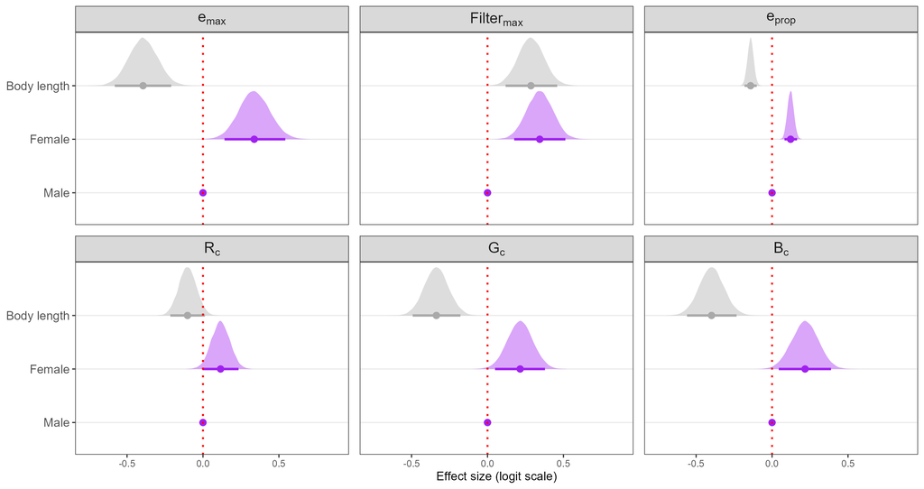

```r
# Convert images to base64
final_plot_posteriors_m4 <- knitr::image_uri("C:/Users/bmc82/Documents/UF/PhD_Projects/DISSERTATION_MANUSCRIPT/Chapter_3/chapter3_data_analysis/images/final_plot_posteriors_m4.png")

# Create the HTML
html_m4_posteriors_WNAN_final <- paste0("
  <style>
    .image-row {
      display: flex;
      gap: 20px;
      justify-content: center;
      align-items: flex-start;
    }
    .image-row img {
      max-width: 100%;
      height: auto;
      border: 1px solid #ccc;
    }
  </style>
<div class='image-row'>
  <img src='", final_plot_posteriors_m4, "' alt='Final Microhabitat Posterior Plot'>
</div>
")

# Display the HTML
IRdisplay::display_html(html_m4_posteriors_WNAN_final)
```

Contents